# Chilean prosecutor’s office Data merge (Step 4)

```css
script src = "https://ajax.googleapis.com/ajax/libs/jquery/3.4.1/jquery.min.js"
```

```javascript
 $(document).ready(function() {
    $('body').prepend('<div class=\"zoomDiv\"><img src=\"\" class=\"zoomImg\"></div>');
    // onClick function for all plots (img's)
    $('img:not(.zoomImg)').click(function() {
      $('.zoomImg').attr('src', $(this).attr('src')).css({width: '100%'});
      $('.zoomDiv').css({opacity: '1', width: 'auto', border: '1px solid white', borderRadius: '5px', position: 'fixed', top: '50%', left: '50%', marginRight: '-50%', transform: 'translate(-50%, -50%)', boxShadow: '0px 0px 50px #888888', zIndex: '50', overflow: 'auto', maxHeight: '100%'});
    });
    // onClick function for zoomImg
    $('img.zoomImg').click(function() {
      $('.zoomDiv').css({opacity: '0', width: '0%'});
    });
  });
```

```css
<script src="hideOutput.js"></script>
```

```javascript
$(document).ready(function() {
    $chunks = $('.fold');
    $chunks.each(function () {      // add button to source code chunks
    if ( $(this).hasClass('s') ) {
        $('pre.r', this).prepend("<div class=\"showopt\">Show Source</div><br style=\"line-height:22px;\"/>");
            $('pre.r', this).children('code').attr('class', 'folded');
            }      // add button to output chunks
        if ( $(this).hasClass('o') ) {
            $('pre:not(.r)', this).has('code').prepend("<div class=\"showopt\">Show Output</div><br style=\"line-height:22px;\"/>");
            $('pre:not(.r)', this).children('code:not(r)').addClass('folded');        // add button to plots
            $(this).find('img').wrap('<pre class=\"plot\"></pre>');
            $('pre.plot', this).prepend("<div class=\"showopt\">Show Plot</div><br style=\"line-height:22px;\"/>");
            $('pre.plot', this).children('img').addClass('folded');
            }
});    // hide all chunks when document is loaded
    $('.folded').css('display', 'none')    // function to toggle the visibility
    $('.showopt').click(function() {
            var label = $(this).html();
            if (label.indexOf("Show") >= 0) {
                $(this).html(label.replace("Show", "Hide"));
            } else {
              $(this).html(label.replace("Hide", "Show"));
            }
    $(this).siblings('code, img').slideToggle('fast', 'swing');
    });
});
```

- Rename variables according to studied names
- We filtered relationships with a result of the proceeding with the value “FINAL JUDGMENT GUILTY” (“SENTENCIA DEFINITIVA CONDENATORIA”)
- In this section, we tried to identify the offenders of interest.
- Also we explored the type of sentence by those that had a condemnatory sentence.
- We corrected the coded types of offenses to include PREDATORY ACTS

# Group offenses

We discussed the nature of offenses with several professionals in the judiciary system and expert lawyers. As a result, categorized offenses differently as shown in the following document.

```r
Agrupacion_de_delitos_Fiscalia_Final_26_10_2022_ <- readxl::read_excel("Agrupacion de delitos Fiscalia Final (26-10-2022).xlsx")

Agrupacion_de_delitos_Fiscalia_Final_26_10_2022_ %>%
  knitr::kable("markdown")
```

| Delito | Delitos relacionados al consumo de sustancias (drogas y alcohol) | Delitos violentos | Delitos adquisitivos | Otros delitos | Comentarios/dudas equipo investigador | Respuesta Diego Rochow | Comentarios Mariel segunda revision |
| --- | --- | --- | --- | --- | --- | --- | --- |
| ABANDONO DE ARMAS O ELEMENTOS SUJETAS A CONTROL. ART. 14 A. |  |  |  | X | Favor corroborar si hace sentido. Hemos encontrado literatura que incorpora el porte de armas bajo la categoria de delitos adquisitivos. | Este delito es muy sui generis del caso chileno. La verdad es que no entiendo muy bien cuál es la racionalidad por la que se penaliza. Pese a ello, no me hace sentido considerarlo un delito contra la … |  |
| ABANDONO DE CÓNYUGE O DE PARIENTES ENFERMOS. ART. 352. |  |  |  | X |  |  |  |
| ABANDONO DE NIÑOS |  |  |  | X |  |  |  |
| ABANDONO O MALTRATO ANIMAL ART.291 BIS. |  |  |  | X | Algunas investigaciones consideran el maltrato animal dnentro de la categoria de crimenes violentos, sin embargo, debido a que se agrupa con abandono, decidimos no considerarlo. Favor corroborar si ha… | Sí, totalmente de acuerdo. En la literatura criminológica, al menos, no se suele incluir como delito violento. Me hace sentido que sea “Otros”. |  |
| ABIGEATO |  |  |  | X |  |  |  |
| ABORTO COMETIDO POR FACULTATIVO POR CAUSALES NO REGULADAS |  |  |  | X |  |  |  |
| ABORTO CONSENTIDO POR CAUSLAES N/REGULADAS ART 342 N 3 Y 344 |  |  |  | X |  |  |  |
| ABORTO SIN CONSENTIMIENTO |  |  |  | X |  |  |  |
| ABUSO DE FIRMA EN BLANCO |  |  |  | X |  |  |  |
| ABUSO SEX C/CONTACTO CORP. A MENOR DE 14 AÑOS ART 366 BIS |  | X |  |  |  |  |  |
| ABUSO SEX MAYOR 14/MENOR 18 CON CIRCUNS ESTUPRO ART 366 INC2 |  | X |  |  |  |  |  |
| ABUSO SEX MAYOR DE 14 AÑOS POR SORPRESA Y/O S/CONSENTIM. ART |  | X |  |  |  |  |  |
| ABUSO SEX. S/CONTAC MAYOR 14 MENOR 18 ART 366 QUAT INC 3,4,5 |  | X |  |  |  |  |  |
| ABUSO SEX. S/CONTACTO CORP. MENOR 14 ART 366 QUAT. INC 1 Y 2 |  | X |  |  |  |  |  |
| ABUSO SEXUAL CALIFICADO (CON OBJETOS O ANIMALES)ART.365 BIS |  | X |  |  |  |  |  |
| ABUSO SEXUAL DE MAYOR DE 14 (CON CIRC. DE VIOLACIÓN) ART 366 |  | X |  |  |  |  |  |
| ABUSOS CONTRA PARTICULARES.ARTS. 255. |  |  |  | X |  |  |  |
| ACCIDENTE CON RESUL. MUERTE O LES.GRAVES ART.196 C LEY 18290 |  |  |  | X |  |  |  |
| ADQ. O ALMACENAMIENTO MAT.PORNOGRÁFICO INF.ART.374 BIS INC 2 |  |  |  | X |  |  |  |
| ALLANAMIENTOS IRREGULARES |  |  |  | X |  |  |  |
| AMENAZA A FISCAL O DEFENSOR EN DESEMP. DE FUNC. ART 268 QUIN |  |  |  | X |  |  |  |
| AMENAZA CON ARMA (FALTA) ART. 494 Nº4 CÓDIGO PENAL |  | X |  |  | Favor corroborar si hace sentido. Hemos encontrado literatura que incorpora el porte de armas bajo la categoria de delitos adquisitivos. | No me hace sentido. Lo que se sanciona es la violencia que implica amenazar con armas. No hay, en este delito, una infracción contra la propiedad que permita asumir que necesariamente es una acción “a… |  |
| AMENAZA GENDARME EN DESEMP. DE FUNC. ART 15 D DL 2589 |  |  |  | X |  | *Estos delitos de amenazas también podrían considerarse como delitos violentos, o que atentan contra las personas. Valdría darle una vuelta, en función de la cantidad que encuentren, a ver si vale la … | Creo que no estoy de acuerdo con Diego porque me ha tocado ver como gendarmeria no siempre actua de buena fe identificando a quienes causan violencia |
| AMENAZAR U OFENDER A FUNC DE INVESTIGACIONES. ART. 17 quáter |  |  |  | X |  |  |  |
| AMENAZAS A CARABINEROS |  |  |  | X |  |  |  |
| AMENAZAS CONDIC. CONTRA PERSONAS Y PROP. ART. 296 1 y 2, 297 |  |  |  | X |  |  |  |
| AMENAZAS DE ATENTADOS CONTRA PERSONAS Y PROPIEDADES |  |  |  | X |  |  |  |
| AMENAZAS SIMPLES CONTRA PERSONAS Y PROPIEDADES ART. 296 Nº3. |  |  |  | X |  |  |  |
| APERTURA, REG. O INTERCEPTACIÓN DE CORRESP. ART.146 Y 156 |  |  |  | X |  |  |  |
| APREMIOS ILEG. COMETIDOS POR EMPL. PÚBLICOS. (ART. 150 D) |  | X |  |  | Favor corroborar si hace sentido esta clasificacion. | Sí, se sanciona como una forma especial de violencia. Hace sentido. |  |

[output cut: 299 more lines]

Time for this code chunk to run: 0 minutes

This new categorization was named as `familia_delito_rec_prof`.

```r
Base_fiscalia_v8<-
  Base_fiscalia_v8 %>%
  dplyr::left_join(Agrupacion_de_delitos_Fiscalia_Final_26_10_2022_[,1:5],
                   by=c("gls_materia"="Delito")) %>%
  dplyr::mutate(familia_delito_rec_prof= dplyr::case_when(nchar(`Delitos relacionados al consumo de sustancias (drogas y alcohol)`)>0~ "Substance-related", nchar(`Delitos violentos`)>0~ "Violent", nchar(`Delitos adquisitivos`)>0~ "Acquisitive", nchar(`Otros delitos`)>0~ "Other", T~ NA_character_)) %>%
 purrr::when(dplyr::mutate(., tot_off = base::rowSums(dplyr::select(.,c(`Delitos relacionados al consumo de sustancias (drogas y alcohol)`,`Delitos violentos`, `Delitos adquisitivos`, `Otros delitos`))%>% dplyr::mutate_all(~nchar(.)>0,1,0), na.rm = T))%>% dplyr::filter(tot_off==0|tot_off>1) %>% nrow(.)>0 ~ stop("there are crimes with no category of more than one"), ~.) %>%
  dplyr::select(-`Delitos relacionados al consumo de sustancias (drogas y alcohol)`,-`Delitos violentos`, -`Delitos adquisitivos`, -`Otros delitos`)
#dplyr::mutate(gls_materia_na=!is.na(gls_materia)) #janitor::tabyl(gls_materia_na,familia_delito_rec_prof)
```

Time for this code chunk to run: 0 minutes

# Filter cases

We discarded relationships in which the subject considered an offender was not the patient from SENDA. Also we restricted the analysis to the patients that had a final judgment as guilty with a condemnatory sentence (“SENTENCIA DEFINITIVA CONDENATORIA”), compensation agreements (“ACUERDO REPARATORIO”), suspended finishing of the proceedings (“SUSPENSION CONDICIONAL DEL PROCEDIMIENTO”) and definitive dismissal (“SOBRESEIMIENTO DEFINITIVO”) provided they were nested to the Article 240 of the Civil Procedure Code.

```r
Base_fiscalia_v9<-
  plyr::rename(Base_fiscalia_v8,
c('rut_enc_saf' = 'id',
'fec_nacimiento' = 'dateofbirth',
'pais' = 'country',
'sexo' = 'sex',
'encontrado_como_victima' = 'victim',
'encontrado_como_imputado' = 'offender_d',
'tipo_sujeto_vic' = 'victim_type_n',
'gls_tipo_sujeto_vic' = 'victim_type_c',
'idsujeto_victima' = 'id_victim',
'reg' = 'reg',
'gls_region' = 'reg_c',
'idrelacion' = 'id_relac',
'ruc' = 'caseid',
'tipo_termino' = 'end_type_group',
'agrupa_terminos' = 'end_type',
'cod_delito' = 'crime_code',
'gls_materia' = 'crime_code_c',
'familia_delito' = 'crime_code_group',
'cod_mottermino' = 'end_type_2c',
'gls_mottermino' = 'end_type_2',
'impcod_tiposujeto' = 'offender_type',
'gls_tipo_imputado' = 'offender_type2',
'iddelito' = 'offence_type',
'fec_comision' = 'date_offending',
'marca_pena_44' = 's_sentence_1',
'marca_multa_45' = 's__fine_1',
'medida_alternativa_46' = 's_restorative_3',
'clasificacion_pena_47' = 's_kindprison_1',
'marca_pena_52' = 's_sentence_2',
'marca_multa_53' = 's__fine_2',
'medida_alternativa_54' = 's_restorative_2',
'clasificacion_pena_55' = 's_kindprison_2',
'imp_birth_date' = 'dateofbirth_imp',
'obs' = 'obs',
'edad_comision_imp' = 'age_offending_imp',
'edad_ter_rel_imp' = 'age_finish_rel_imp',
'familia_delito_rec' = 'crime_code_group_rec',
'familia_delito_rec_prof' = 'crime_code_group_rec_prof',
'sex_imp' = 'sex_imp',
'nat_imp2' = 'country_b',
'nat_imp' = 'country_a')) %>%
#FILTER IF THE PATIENT IS CONSIDERED AS AN OFFENDER
  dplyr::filter(grepl("SI",offender_d)) %>%
#FILTER IF THE PATIENT RECIEVES FOR THE RELATIONSHIP
  #end_type agrupa end_type_2 gls_mottermino
  dplyr::mutate(filter=dplyr::case_when(
  grepl("REPARATORIO|CONDICIONAL",end_type) & is.na(end_type_2)~1,
    grepl("REPARATORIO|SENTENCIA DEFINITIVA CONDENATORIA|240|MONIT", toupper(end_type_2), ignore.case=F)~2,
  T~0
  )) %>%
  dplyr::filter(filter>0)%>%

  #FORMAT TO SQLDF
  dplyr::group_by(id) %>%
  dplyr::mutate(rn_id=dplyr::row_number()) %>%
  dplyr::mutate(obs=as.character(obs)) %>%
  dplyr::ungroup() %>%
  as.data.table()
```

Time for this code chunk to run: 0.1 minutes

We ended with 174,961 relationships of 152,766 court cases (`caseid`) of 49,970 patients. Then, we coded the crimes according to a classification discussed in formal consultations with professionals.

```r
Base_fiscalia_v9<-
  Base_fiscalia_v9 %>%
  dplyr::mutate(s_kindprison_1=dplyr::case_when(
    s_kindprison_1== 'Presidio Mayor grado medio' ~ 'Major Prison medium grade',
    s_kindprison_1== 'Presidio Mayor grado máximo' ~ 'Major Prison maximum grade',
    s_kindprison_1== 'Presidio Mayor grado mínimo' ~ 'Major Prison minimum degree',
    s_kindprison_1== 'Presidio Menor grado medio' ~ 'Minor Prison medium grade',
    s_kindprison_1== 'Presidio Menor grado máximo' ~ 'Minor Prison maximum degree',
    s_kindprison_1== 'Presidio Menor grado mínimo' ~ 'Minimum term of imprisonment',
    s_kindprison_1== 'Presidio Perpetuo calificado' ~ 'Life imprisonment, qualified degree',
    s_kindprison_1== 'Presidio Perpetuo simple' ~ 'Simple life imprisonment',
    s_kindprison_1== 'Prisión' ~ 'Prison',
    T~ s_kindprison_1)) %>%
  #Added at 2022-11-11
#STATA= replace prision_fact=1 if s_sentence_1=="SI" & s_restorative_3!="Libertad Vigilada"& s_restorative_3!="Otra"& s_restorative_3!="Reclusión Nocturna"& s_restorative_3!="Remisión Condicional".
  dplyr::mutate(prision_fact= dplyr::case_when(s_sentence_1=="SI" & is.na(s_restorative_3)~1, T~0)) %>%
  purrr::when(nrow(.)-nrow(Base_fiscalia_v8)>0 ~ stop("more than one case by row"), ~.)
  # dplyr::select(id, caseid, victim, offender_d, victim_type_n, victim_type_c, id_victim, id_relac, reg, reg_c, end_type_group, end_type, crime_code, crime_code_c, crime_code_group, end_type_2c, end_type_2, offender_type, offender_type2, offence_type, date_offending, s_sentence_1, s__fine_1, s_restorative_3, s_kindprison_1, s_sentence_2, s__fine_2, s_restorative_2, s_kindprison_2, dateofbirth_imp, obs, date_offending_imp, age_offending_imp, crime_code_group_rec_prof, sex_imp, country_b, country_a) %>%
  # dplyr::mutate(dob_imp_num= dplyr::case_when(!is.na(dob_imp_num) & dob_imp_num!=fech_nac_num~ dob_imp_num, !is.na(dob_imp_num) & is.na(fech_nac_num)~ dob_imp_num, T~fech_nac_num)) %>%
```

Time for this code chunk to run: 0 minutes

# Explore values

We saw the relationships by RUN(`id`) and RUC (`caseid`).

```r
#- clasificacion_pena_47 #CHANGE GRADE FOR LENGTH
concatenated_run_ruc_n_rel_n_offenses<-
Base_fiscalia_v9 %>%
  dplyr::group_by(id, caseid) %>%
  dplyr::summarise(n=n(), n_distinct_offenses=n_distinct(crime_code_c))
```

`summarise()` has grouped output by ‘id’. You can override using the `.groups` argument.

```r
#plot(cut2(concatenated_run_ruc_n_rel_n_offenses$n_distinct_offenses), main= "Number of different crimes committed within a case, by patients")

#more than 1 different offenses
concatenated_run_ruc_n_rel_n_offenses_f1<-
Base_fiscalia_v9 %>%
  group_by(id, caseid) %>%
  dplyr::summarise(n=n(), n_distinct_offenses=n_distinct(crime_code_c)) %>%
  dplyr::filter(n_distinct_offenses>1)
```

group_by: 2 grouping variables (id, caseid) `summarise()` has grouped output by ‘id’. You can override using the `.groups` argument.

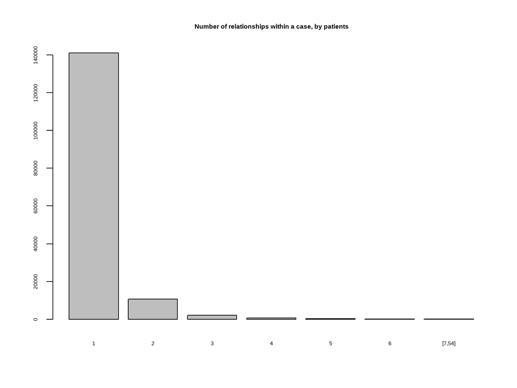

```r
warning(paste0("There are ",length(unique(concatenated_run_ruc_n_rel_n_offenses_f1$caseid)), " rucs with more than one crime within a case"))

plot(cut2(concatenated_run_ruc_n_rel_n_offenses$n), main= "Number of relationships within a case, by patients")
```

Time for this code chunk to run: 0.3 minutes

```r
concatenated_run_ruc_n_rel_n_offenses %>% dplyr::ungroup() %>%  dplyr::mutate(n=cut2(n),n_distinct_offenses=cut2(n_distinct_offenses)) %>% dplyr::group_by(n, n_distinct_offenses) %>% count() %>% dplyr::ungroup() %>% dplyr::mutate(perc=round(nn/sum(nn)*100,2)) %>%
  knitr::kable("markdown", col.names = c("Number of relationships by RUC(caseid)", "Number of distinct offenses by RUC (caseid)", "n of relationships", "%"))
```

Storing counts in `nn`, as `n` already present in input count: now 25 rows and 3 columns, 2 group variables remaining (n, n_distinct_offenses) i Use `name = "new_name"` to pick a new name.

| Number of relationships by RUC(caseid) | Number of distinct offenses by RUC (caseid) | n of relationships | % |
| --- | --- | --- | --- |
| 1 | 1 | 141060 | 90.95 |
| 2 | 1 | 4614 | 2.98 |
| 2 | 2 | 6105 | 3.94 |
| 3 | 1 | 712 | 0.46 |
| 3 | 2 | 687 | 0.44 |
| 3 | 3 | 670 | 0.43 |
| 4 | 1 | 182 | 0.12 |
| 4 | 2 | 309 | 0.20 |
| 4 | 3 | 159 | 0.10 |
| 4 | 4 | 69 | 0.04 |
| 5 | 1 | 67 | 0.04 |
| 5 | 2 | 68 | 0.04 |
| 5 | 3 | 101 | 0.07 |
| 5 | 4 | 29 | 0.02 |
| 5 | [5,7] | 8 | 0.01 |
| 6 | 1 | 21 | 0.01 |
| 6 | 2 | 39 | 0.03 |
| 6 | 3 | 33 | 0.02 |
| 6 | 4 | 17 | 0.01 |
| 6 | [5,7] | 6 | 0.00 |
| [7,54] | 1 | 35 | 0.02 |
| [7,54] | 2 | 27 | 0.02 |
| [7,54] | 3 | 42 | 0.03 |
| [7,54] | 4 | 16 | 0.01 |
| [7,54] | [5,7] | 16 | 0.01 |

Time for this code chunk to run: 0 minutes

Most cases had only one relationship, and nearly 95% had only one offense (even if the number of relationships is greater). We showed details.

```r
Base_fiscalia_v9 %>%
  dplyr::filter(caseid %in%
as.character(unlist(distinct(dplyr::filter(dplyr::ungroup(concatenated_run_ruc_n_rel_n_offenses),n>1),caseid)))) %>%
  dplyr::select(id, dateofbirth_imp, sex_imp, country_a, caseid, id_relac, id_victim, age_offending_imp, age_finish_rel_imp, crime_code_c, reg_c, end_type_2, s_sentence_1, s__fine_1, s_kindprison_1, s_sentence_2, s__fine_2, s_kindprison_2, prision_fact) %>%
  slice(1:40) %>%
  knitr::kable("markdown", caption="Glimpse of the database")
```

distinct: removed 157 rows (1%), 13,875 rows remaining

slice: removed 33,946 rows (>99%), 40 rows remaining

Table 1: Glimpse of the database

| id | dateofbirth_imp | sex_imp | country_a | caseid | id_relac | id_victim | age_offending_imp | age_finish_rel_imp | crime_code_c | reg_c | end_type_2 | s_sentence_1 | s__fine_1 | s_kindprison_1 | s_sentence_2 | s__fine_2 | s_kindprison_2 | prision_fact |
| --- | --- | --- | --- | --- | --- | --- | --- | --- | --- | --- | --- | --- | --- | --- | --- | --- | --- | --- |
| 000a62a4c9e376a2032337e7e7f8eb37 | 1974-01-03 | Men | CHILE | 1700750803-4 | 23268511 | 66230612 | 43.60575 | 44.30664 | HURTO SIMPLE POR UN VALOR DE MEDIA A 4 UTM | RM Centro Norte | Sentencia definitiva condenatoria | SI | NO | Prison |  |  |  | 1 |
| 000a62a4c9e376a2032337e7e7f8eb37 | 1974-01-03 | Men | CHILE | 1700750803-4 | 24565685 | 66230612 | 44.00548 | 44.30664 | HURTO SIMPLE POR UN VALOR DE MEDIA A 4 UTM | RM Centro Norte | Sentencia definitiva condenatoria | SI | NO | Prison |  |  |  | 1 |
| 001a5f8af444cee67957c0ec408fc899 | 1990-07-19 | Men | CHILE | 1310020538-0 | 15955850 | 44532404 | 22.96235 | 24.41889 | LESIONES MENOS GRAVES | IX Región de la Araucanía | Acuerdo Reparatorio (Art. 241 y 242) |  |  |  |  |  |  | 0 |
| 001a5f8af444cee67957c0ec408fc899 | 1990-07-19 | Men | CHILE | 1310020538-0 | 15955849 | 44526809 | 22.96235 | 23.37303 | LESIONES MENOS GRAVES | IX Región de la Araucanía | Acuerdo Reparatorio (Art. 241 y 242) |  |  |  |  |  |  | 0 |
| 001a5f8af444cee67957c0ec408fc899 | 1990-07-19 | Men | CHILE | 1310020538-0 | 15955851 | 44532422 | 22.96235 | 23.37303 | LESIONES MENOS GRAVES | IX Región de la Araucanía | Acuerdo Reparatorio (Art. 241 y 242) |  |  |  |  |  |  | 0 |
| 001b0ff241cd0d95828b86b4bdab8c19 | 1967-06-30 | Men | CHILE | 1500667994-0 | 19585596 | 55280333 | 48.03559 | 48.03833 | ROBO POR SORPRESA. ART. 436 INC. 2° | RM Occidente | Sentencia definitiva condenatoria | SI | NO | Minimum term of imprisonment |  |  |  | 0 |
| 001b0ff241cd0d95828b86b4bdab8c19 | 1967-06-30 | Men | CHILE | 1500667994-0 | 19585597 | 55280335 | 48.03559 | 48.03833 | ROBO POR SORPRESA. ART. 436 INC. 2° | RM Occidente | Sentencia definitiva condenatoria | SI | NO | Minimum term of imprisonment |  |  |  | 0 |
| 001ea201acc13db63b00bbfbb9699a1f | 1985-08-08 | Men | CHILE | 1800123994-1 | 24132324 | 68822480 | 32.48734 | 33.62628 | AMENAZAS SIMPLES CONTRA PERSONAS Y PROPIEDADES ART. 296 Nº3. | XIV Región de los Rios | Sentencia definitiva condenatoria | SI | NO | Minimum term of imprisonment |  |  |  | 1 |
| 001ea201acc13db63b00bbfbb9699a1f | 1985-08-08 | Men | CHILE | 1800123994-1 | 26249716 | 68822480 | 32.57221 | 33.62628 | AMENAZAS SIMPLES CONTRA PERSONAS Y PROPIEDADES ART. 296 Nº3. | XIV Región de los Rios | Sentencia definitiva condenatoria | SI | NO | Minimum term of imprisonment |  |  |  | 1 |
| 001fb4d82755ca201c292fe318fef341 | 1963-12-14 | Men | CHILE | 1600857872-2 | 21653821 | 61416183 | 52.74196 | 53.00753 | AMENAZAS SIMPLES CONTRA PERSONAS Y PROPIEDADES ART. 296 Nº3. | RM Sur | Sentencia definitiva condenatoria | SI | NO | Prison |  |  |  | 0 |
| 001fb4d82755ca201c292fe318fef341 | 1963-12-14 | Men | CHILE | 1600857872-2 | 21676613 | 61482729 | 52.74196 | 53.00753 | AMENAZAS SIMPLES CONTRA PERSONAS Y PROPIEDADES ART. 296 Nº3. | RM Sur | Sentencia definitiva condenatoria | SI | NO | Prison |  |  |  | 0 |
| 00237788c4c803c12fecac82105ea4f0 | 1982-08-26 | Men | CHILE | 1000167971-1 | 9570867 | 26254229 | 27.47981 | 27.49897 | LESIONES LEVES | VII Región del Maule | Acoge req. proced monit y proposic multa |  |  |  |  |  |  | 0 |
| 00237788c4c803c12fecac82105ea4f0 | 1982-08-26 | Men | CHILE | 1000167971-1 | 9570868 | 26254230 | 27.47981 | 27.49897 | LESIONES LEVES | VII Región del Maule | Acoge req. proced monit y proposic multa |  |  |  |  |  |  | 0 |
| 002c979e254773f17812d9bff13996dc | 1983-12-05 | Men | CHILE | 1200372112-2 | 19515028 | 37887208 | 28.33128 | 31.56742 | FALSIFICACIÓN O USO MALICIOSO DE DOC. PRIVADOS ART.197 Y 198 | RM Centro Norte | Sentencia definitiva condenatoria | SI | SI | Minimum term of imprisonment |  |  |  | 1 |
| 002c979e254773f17812d9bff13996dc | 1983-12-05 | Men | CHILE | 1200372112-2 | 13667457 | 37887208 | 28.33128 | 31.56742 | RECEPTACIÓN. ART. 456 BIS A | RM Centro Norte | Sentencia definitiva condenatoria | SI | SI | Minimum term of imprisonment |  |  |  | 1 |
| 002c979e254773f17812d9bff13996dc | 1983-12-05 | Men | CHILE | 1200443291-4 | 14656060 | 38183528 | 28.39973 | 29.30869 | CONSUMO/PORTE EN LUG. PÚB.O PRIV. CON PREV.CONCIERTO(ART.50) | RM Oriente | Sentencia definitiva condenatoria | SI | NO | Minimum term of imprisonment |  |  |  | 0 |
| 002c979e254773f17812d9bff13996dc | 1983-12-05 | Men | CHILE | 1200443291-4 | 13771534 | 38183528 | 28.40246 | 29.48118 | RECEPTACIÓN. ART. 456 BIS A | RM Oriente | Sentencia definitiva condenatoria | SI | NO | Prison |  |  |  | 0 |
| 002c979e254773f17812d9bff13996dc | 1983-12-05 | Men | CHILE | 1200582969-9 | 13977463 | 38766117 | 28.50924 | 31.51540 | ESTAFAS Y OTRAS DEFRAUDACIONES CONTRA PARTICULARES | RM Sur | Sentencia definitiva condenatoria | SI | SI | Minimum term of imprisonment |  |  |  | 0 |
| 002c979e254773f17812d9bff13996dc | 1983-12-05 | Men | CHILE | 1200582969-9 | 17933305 | 38766117 | 28.50924 | 31.51540 | FALSIFICACIÓN O USO MALICIOSO DE DOC. PRIVADOS ART.197 Y 198 | RM Sur | Sentencia definitiva condenatoria | SI | SI | Minimum term of imprisonment |  |  |  | 0 |
| 002c979e254773f17812d9bff13996dc | 1983-12-05 | Men | CHILE | 1410038401-K | 20747379 | 58702592 | 30.48323 | 34.98426 | FALSIFICACIÓN O USO MALICIOSO DE DOC. PRIVADOS ART.197 Y 198 | RM Sur | Sentencia definitiva condenatoria | SI | NO | Minor Prison maximum degree |  |  |  | 1 |
| 002c979e254773f17812d9bff13996dc | 1983-12-05 | Men | CHILE | 1410038401-K | 18491090 | 52059498 | 30.48323 | 34.98426 | FALSIFICACIÓN O USO MALICIOSO DE DOC. PRIVADOS ART.197 Y 198 | RM Sur | Sentencia definitiva condenatoria | SI | NO | Minor Prison maximum degree |  |  |  | 1 |
| 002c979e254773f17812d9bff13996dc | 1983-12-05 | Men | CHILE | 1400546111-2 | 17610509 | 49366424 | 30.49692 | 31.30732 | ESTAFAS Y OTRAS DEFRAUDACIONES CONTRA PARTICULARES | VI Región del Libertador Gral. Bernardo O Higgins | Sentencia definitiva condenatoria | SI | SI | Minor Prison medium grade |  |  |  | 1 |
| 002c979e254773f17812d9bff13996dc | 1983-12-05 | Men | CHILE | 1400546111-2 | 17610510 | 49366424 | 30.49692 | 31.30732 | FALSIFICACIÓN O USO MALICIOSO DE DOC. PRIVADOS ART.197 Y 198 | VI Región del Libertador Gral. Bernardo O Higgins | Sentencia definitiva condenatoria | SI | SI | Minor Prison medium grade |  |  |  | 1 |
| 002c979e254773f17812d9bff13996dc | 1983-12-05 | Men | CHILE | 1400546111-2 | 17610511 | 49366424 | 30.49692 | 31.30732 | FALSIFICACION O USO MALICIOSO DE DOCUMENTOS PUBLICOS | VI Región del Libertador Gral. Bernardo O Higgins | Sentencia definitiva condenatoria | SI | SI | Minor Prison medium grade |  |  |  | 1 |
| 002c979e254773f17812d9bff13996dc | 1983-12-05 | Men | CHILE | 1400546111-2 | 18841874 | 53116241 | 30.49692 | 31.30732 | FALSIFICACIÓN O USO MALICIOSO DE DOC. PRIVADOS ART.197 Y 198 | VI Región del Libertador Gral. Bernardo O Higgins | Sentencia definitiva condenatoria | SI | SI | Minor Prison medium grade |  |  |  | 1 |
| 0034f145a61fee1806b3b68e83454ba8 | 1967-07-08 | Men | CHILE | 1100680229-1 | 12163422 | 33574073 | 43.99179 | 43.99452 | LESIONES LEVES | RM Centro Norte |  |  |  |  |  |  |  | 0 |
| 0034f145a61fee1806b3b68e83454ba8 | 1967-07-08 | Men | CHILE | 1100680229-1 | 12146088 | 33574073 | 43.99179 | 43.99452 | AMENAZAS SIMPLES CONTRA PERSONAS Y PROPIEDADES ART. 296 Nº3. | RM Centro Norte |  |  |  |  |  |  |  | 0 |
| 003cced510c978fedf5d21d3050a11d5 | 1990-01-13 | Women | CHILE | 1210037758-4 | 14976199 | 41659355 | 22.94045 | 24.38877 | LESIONES LEVES | VI Región del Libertador Gral. Bernardo O Higgins | Acuerdo Reparatorio (Art. 241 y 242) |  |  |  |  |  |  | 0 |
| 003cced510c978fedf5d21d3050a11d5 | 1990-01-13 | Women | CHILE | 1210037758-4 | 14976200 | 41659355 | 22.94045 | 24.38877 | AMENAZAS SIMPLES CONTRA PERSONAS Y PROPIEDADES ART. 296 Nº3. | VI Región del Libertador Gral. Bernardo O Higgins | Acuerdo Reparatorio (Art. 241 y 242) |  |  |  |  |  |  | 0 |
| 003fca81481730632c73fe445a0543eb | 1988-04-02 | Men | CHILE | 1300048351-0 | 15075404 | 41950377 | 24.78303 | 25.48665 | DAÑOS SIMPLES. ART. 487. | XIV Región de los Rios | Sentencia definitiva condenatoria | SI | SI | Minimum term of imprisonment |  |  |  | 1 |
| 003fca81481730632c73fe445a0543eb | 1988-04-02 | Men | CHILE | 1300048351-0 | 15075405 | 41950405 | 24.78303 | 25.48665 | DAÑOS SIMPLES. ART. 487. | XIV Región de los Rios | Sentencia definitiva condenatoria | SI | SI | Minimum term of imprisonment |  |  |  | 1 |
| 003fca81481730632c73fe445a0543eb | 1988-04-02 | Men | CHILE | 1300048351-0 | 15065106 | 41919322 | 24.78303 | 25.48665 | ROBO POR SORPRESA. ART. 436 INC. 2° | XIV Región de los Rios | Sentencia definitiva condenatoria | SI | NO | Minimum term of imprisonment |  |  |  | 1 |
| 004d1991cbc06fe1959d0d3a23fba572 | 1975-11-09 | Men | CHILE | 1200547345-2 | 13924393 |  | 36.54757 | 40.86516 | PORTE DE ARMA CORTANTE O PUNZANTE (288 bis) | XV Región de Arica y Parinacota | Sentencia definitiva condenatoria |  |  |  |  |  |  | 0 |
| 004d1991cbc06fe1959d0d3a23fba572 | 1975-11-09 | Men | CHILE | 1200547345-2 | 22258263 |  | 37.57153 | 40.86516 | PORTE DE ARMA CORTANTE O PUNZANTE (288 bis) | XV Región de Arica y Parinacota | Sentencia definitiva condenatoria |  |  |  |  |  |  | 0 |
| 004ec0e79c85962bf11905d396903e47 | 1991-11-06 | Men | CHILE | 1200440274-8 | 13767653 | 38172007 | 20.47912 | 22.00137 | HURTO SIMPLE POR UN VALOR DE MEDIA A 4 UTM | X Región de los Lagos | S Definit (vencim plazo suspens art 240) |  |  |  |  |  |  | 0 |
| 004ec0e79c85962bf11905d396903e47 | 1991-11-06 | Men | CHILE | 1200440274-8 | 13767654 | 38172007 | 20.47912 | 22.00137 | RECEPTACIÓN. ART. 456 BIS A | X Región de los Lagos | S Definit (vencim plazo suspens art 240) |  |  |  |  |  |  | 0 |
| 0055c9c7d7d2d6784655e1f3266118a6 | 1975-09-15 | Men | CHILE | 1401176063-6 | 18487122 | 52046464 | 39.21424 | 39.56468 | LESIONES MENOS GRAVES | VIII Región del Bio Bio | Sentencia definitiva condenatoria |  |  |  |  |  |  | 0 |
| 0055c9c7d7d2d6784655e1f3266118a6 | 1975-09-15 | Men | CHILE | 1401176063-6 | 18487121 | 52046463 | 39.21424 | 39.56468 | LESIONES MENOS GRAVES | VIII Región del Bio Bio | Sentencia definitiva condenatoria |  |  |  |  |  |  | 0 |
| 00573de0fa9ec9b24d53bd8d801dd2d7 | 1981-11-26 | Men | CHILE | 1100454581-K | 11821973 | 32628905 | 29.44011 | 29.77960 | USURPACIÓN DE NOMBRE. ART. 214. | V Región de Valparaíso | Sentencia definitiva condenatoria | SI | NO | Minimum term of imprisonment |  |  |  | 1 |
| 00573de0fa9ec9b24d53bd8d801dd2d7 | 1981-11-26 | Men | CHILE | 1100454581-K | 11812546 | 32628905 | 29.44011 | 29.77960 | ROBO POR SORPRESA. ART. 436 INC. 2° | V Región de Valparaíso | Sentencia definitiva condenatoria | SI | NO | Minor Prison medium grade |  |  |  | 1 |

Time for this code chunk to run: 0 minutes

# Join with SENDAs database

We checked and resolved the inconsistencies in male users receiving women-only treatments after imputation.

```r
invisible("Exported database in 22-09-2022")

#2022-11-01, added the age at discharge.
CONS_C1_df_dup_SEP_2020$edad_al_egres <-
#difftime(lubridate::ymd(CONS_C1_df_dup_SEP_2020$fech_egres_imp), lubridate::ymd(CONS_C1_df_dup_SEP_2020 $fech_nac))/365.25
lubridate::time_length(lubridate::interval(lubridate::ymd(CONS_C1_df_dup_SEP_2020 $fech_nac),lubridate::ymd(CONS_C1_df_dup_SEP_2020$fech_egres_imp)),unit="years")

CONS_C1_df_dup_SEP_2020$edad_al_ing_fmt <-
#lubridate::time_length(lubridate::ymd(CONS_C1_df_dup_SEP_2020$fech_ing), lubridate::ymd(CONS_C1_df_dup_SEP_2020 $fech_nac),"years")
lubridate::time_length(lubridate::interval(lubridate::ymd(CONS_C1_df_dup_SEP_2020 $fech_nac),lubridate::ymd(CONS_C1_df_dup_SEP_2020$fech_ing)),unit="years")


CONS_C1_df_dup_SEP_2020_22<-
CONS_C1_df_dup_SEP_2020 %>%
  subset(select= c("hash_key", "fech_nac", "fech_ing", "fech_egres_imp", "dup", "ano_bd_first", "duplicates_filtered", "id_centro", "tipo_centro", "tipo_de_programa_2", "tipo_de_plan_2", "senda", "macrozona", "nombre_region", "comuna_residencia_cod", "escolaridad_rec", "estado_conyugal_2", "compromiso_biopsicosocial", "sexo_2", "edad_al_ing", "edad_al_ing_fmt", "edad_al_egres", "edad_ini_cons", "edad_ini_sus_prin" ,"edad_ini_sus_prin_grupos", "freq_cons_sus_prin", "via_adm_sus_prin_act",
"sus_ini_2_mod", "sus_ini_3_mod", "sus_ini_mod", "con_quien_vive", "sus_principal_mod",
"origen_ingreso_mod", "numero_de_hijos_mod", "tipo_de_vivienda_mod", "tenencia_de_la_vivienda_mod", "rubro_trabaja_mod", "cat_ocupacional", "estatus_ocupacional", "sus_ini_mod_mvv","cat_ocupacional_corr", "condicion_ocupacional_corr", "otras_sus1_mod", "otras_sus2_mod",  "otras_sus3_mod", "fech_ing_num", "fech_egres_num", "motivodeegreso_mod_imp","motivoegreso_derivacion", "evaluacindelprocesoteraputico",
paste0("tipo_de_plan_2_",1:10),paste0("motivodeegreso_mod_imp_",1:10),
paste0("dias_treat_imp_sin_na_",1:10), "dg_trs_cons_sus_or", "dg_total_cie_10", "dg_cie_10_rec", "dg_total_dsm_iv", "dg_dsm_iv_rec", "cnt_diagnostico_trs_fisico", "diagnostico_trs_fisico", "dg_fis_anemia", "dg_fis_card", "dg_fis_in_study", "dg_fis_enf_som", "dg_fis_ets", "dg_fis_hep_alc", "dg_fis_hep_b", "dg_fis_hep_cro", "dg_fis_inf", "dg_fis_otr_cond_fis_ries_vit", "dg_fis_otr_cond_fis", "dg_fis_pat_buc", "dg_fis_pat_ges_intrau", "dg_fis_trau_sec", "otros_pr_sm_abu_sex", "otros_pr_sm_exp_com_sex", "otros_pr_sm_otros", "otros_pr_sm_vif")) %>%
  purrr::when(dplyr::filter(.,abs(edad_al_ing_fmt-edad_al_ing)>0.02) %>% nrow()>0 ~ stop("Age at admission was calculated differently"), ~.) %>%
    dplyr::mutate(edad_al_ing=edad_al_ing_fmt) %>%
    dplyr::mutate(comorbidity_icd_10=dplyr::case_when(dg_total_cie_10>=2~ "Two or more", dg_total_cie_10==1~ "One", as.character(dg_cie_10_rec)=="Diagnosis unknown (under study)"~"Diagnosis unknown (under study)", as.character(dg_cie_10_rec)=="Without psychiatric comorbidity"~"Without psychiatric comorbidity")) %>%
  dplyr::mutate(comorbidity_icd_10=as.factor(comorbidity_icd_10)) %>%
    dplyr::mutate(estatus_ocupacional=  dplyr::case_when(!is.na(cat_ocupacional)&!is.na(estatus_ocupacional)~"Empleado", TRUE~as.character(estatus_ocupacional)))%>%
  dplyr::mutate(estatus_ocupacional= as.factor(estatus_ocupacional))%>%
  dplyr::mutate(cnt_mod_cie_10_dg_cons_sus_or= dplyr::case_when(as.character(dg_trs_cons_sus_or)== "Drug dependence"~ dg_total_cie_10+1, TRUE~dg_total_cie_10))%>%
  dplyr::mutate(freq_cons_sus_prin=  dplyr::case_when(as.character(freq_cons_sus_prin)=="Did not use"~ "Less than 1 day a week", TRUE~as.character(freq_cons_sus_prin)))%>%
  dplyr::mutate(freq_cons_sus_prin= as.factor(freq_cons_sus_prin)) %>%
    dplyr::mutate(tipo_centro_pub=  factor(dplyr::if_else(as.character(tipo_centro)=="Public",TRUE,FALSE,NA))) %>%  dplyr::mutate(dg_trs_fis_rec=  factor(dplyr::case_when(as.character(diagnostico_trs_fisico)=="En estudio"~"Diagnosis unknown (under study)",as.character(diagnostico_trs_fisico)=="Sin trastorno"~'Without physical comorbidity',cnt_diagnostico_trs_fisico>0 ~'With physical comorbidity',
                                             TRUE~NA_character_)))%>%
    dplyr::mutate(escolaridad_rec= readr::parse_factor(as.character(escolaridad_rec), levels=c('3-Completed primary school or less', '2-Completed high school or less', '1-More than high school'), ordered=T,trim_ws=T,include_na =F, locale=readr::locale(encoding = "Latin1"))) %>%
dplyr::mutate(freq_cons_sus_prin= readr::parse_factor(as.character(freq_cons_sus_prin), levels=c('Did not use', 'Less than 1 day a week','2 to 3 days a week','4 to 6 days a week','1 day a week or more','Daily'), ordered =T,trim_ws=T,include_na =F, locale=readr::locale(encoding = "UTF-8"))) %>%
  dplyr::mutate(evaluacindelprocesoteraputico= dplyr::case_when(grepl("1",as.character(evaluacindelprocesoteraputico))~ '1-High Achievement',grepl("2",as.character(evaluacindelprocesoteraputico))~ '2-Medium Achievement',grepl("3",as.character(evaluacindelprocesoteraputico))~ '3-Minimum Achievement', TRUE~as.character(evaluacindelprocesoteraputico))) %>%
  dplyr::mutate(evaluacindelprocesoteraputico= readr::parse_factor(as.character(evaluacindelprocesoteraputico),levels=c('1-High Achievement', '2-Medium Achievement','3-Minimum Achievement'), ordered =T,trim_ws=T,include_na =F, locale=readr::locale(encoding = "UTF-8"))) %>%
    dplyr::mutate(tenencia_de_la_vivienda_mod= factor(dplyr::case_when(tenencia_de_la_vivienda_mod=="Allegado"~"Stays temporarily with a relative", tenencia_de_la_vivienda_mod=="Arrienda"~"Renting", tenencia_de_la_vivienda_mod=="Cedida"~"Owner/Transferred dwellings/Pays Dividends", tenencia_de_la_vivienda_mod=="Ocupación Irregular"~"Illegal Settlement", tenencia_de_la_vivienda_mod=="Otros"~"Others", tenencia_de_la_vivienda_mod=="Paga dividendo"~"Owner/Transferred dwellings/Pays Dividends", tenencia_de_la_vivienda_mod=="Propia"~"Owner/Transferred dwellings/Pays Dividends", T~NA_character_))) %>%
  dplyr::mutate(freq_cons_sus_prin=dplyr::case_when(freq_cons_sus_prin=="1 day a week or less"~"1 day a week or more",T~as.character(freq_cons_sus_prin))) %>%
  dplyr::mutate(freq_cons_sus_prin=ordered(freq_cons_sus_prin,levels=c("Did not use", "Less than 1 day a week", "1 day a week or more", "2 to 3 days a week","4 to 6 days a week", "Daily"))) %>%
  data.table::data.table() %>%
  dplyr::group_by(hash_key) %>%
  dplyr::mutate(rn_hash_discard=row_number())%>%
  dplyr::ungroup() %>%
  dplyr::mutate(fech_ing_num_discard=fech_ing_num, fech_egres_num_discard= fech_egres_num, fech_ing_discard= fech_ing, fech_egres_imp_discard=fech_egres_imp)%>%
  #WIDE
   tidyr::pivot_wider(
    names_from =  rn_hash_discard,
    names_sep="_",
    values_from = c(fech_ing_num_discard, fech_egres_num_discard, edad_al_ing, edad_al_egres, fech_ing_discard, fech_egres_imp_discard))%>%
  #FILL COLUMNS BY PATIENT
     dplyr::group_by(hash_key)%>%
  dplyr::mutate_at(vars(fech_ing_num_discard_1:fech_egres_num_discard_10),~suppressWarnings(max(as.character(.),na.rm=T)))%>%
    dplyr::mutate_at(vars(edad_al_ing_1:edad_al_ing_10),~suppressWarnings(max(as.character(.),na.rm=T)))%>%
  #2022-11-01, added the age at discharge and the dates
   dplyr::mutate_at(vars(edad_al_egres_1:edad_al_egres_10),~suppressWarnings(max(as.character(.),na.rm=T)))%>%
  dplyr::mutate_at(vars(fech_ing_discard_1:fech_ing_discard_10),~suppressWarnings(max(as.character(.),na.rm=T)))%>%
  dplyr::mutate_at(vars(fech_egres_imp_discard_1:fech_egres_imp_discard_10),~suppressWarnings(max(as.character(.),na.rm=T)))%>%
  dplyr::ungroup() %>%
  purrr::when(nrow(.)>nrow(CONS_C1_df_dup_SEP_2020) ~ stop("More cases in the new database"), ~.)


name_vec <- setNames(c(paste0("fech_ing_num_discard_",1:10), paste0("fech_egres_num_discard_",1:10), paste0("fech_ing_discard_",1:10), paste0("fech_egres_imp_discard_",1:10)),
#names:
                     c(paste0("fech_ing_num_",1:10), paste0("fech_egres_num_",1:10), paste0("fech_ing_",1:10), paste0("fech_egres_imp_",1:10)))
# #_#_#_#_#_#_#_#_#_#_#_#_#_#_#_#_#_#_#_#_#_#_#_#_# #_#_#_#_#_#_#_#_#_#_#_#_#_#_#_#_#_#_#_#_#_#_#_#_

# #_#_#_#_#_#_#_#_#_#_#_#_#_#_#_#_#_#_#_#_#_#_#_#_# #_#_#_#_#_#_#_#_#_#_#_#_#_#_#_#_#_#_#_#_#_#_#_#_
# #_#_#_#_#_#_#_#_#_#_#_#_#_#_#_#_#_#_#_#_#_#_#_#_
# Transform into numeric wide variables
CONS_C1_df_dup_SEP_2020_22_b<-
CONS_C1_df_dup_SEP_2020_22 %>%
  rename(!!!name_vec) %>%
  dplyr::mutate_at(vars(fech_ing_num_1:fech_ing_num_10),~suppressWarnings(as.numeric(.)))%>%
  dplyr::mutate_at(vars(fech_egres_num_1:fech_egres_num_10),~suppressWarnings(as.numeric(.)))%>%
  dplyr::mutate_at(vars(edad_al_ing_1:edad_al_ing_10),~suppressWarnings(as.numeric(.)))%>%
  dplyr::mutate_at(vars(edad_al_egres_1:edad_al_egres_10),~suppressWarnings(as.numeric(.)))%>%
  as.data.table()%>%
  purrr::when(nrow(.)>nrow(CONS_C1_df_dup_SEP_2020_22) ~ stop("More cases in the new database"), ~.)
```

rename: renamed 40 variables (fech_ing_num_1, fech_ing_num_2, fech_ing_num_3, fech_ing_num_4, fech_ing_num_5, …)

```r
# #_#_#_#_#_#_#_#_#_#_#_#_#_#_#_#_#_#_#_#_#_#_#_#_#
# Previous join and resolution of inconsistencies
#_#_#_#_#_#_#_#_#_#_#_#_#_#_#_#_#_#_#_#_#_#_#_#_
# #_#_#_#_#_#_#_#_#_#_#_#_#_#_#_#_#_#_#_#_#_#_#_#_
CONS_C1_df_dup_SEP_2020_22_c<-
CONS_C1_df_dup_SEP_2020_22_b %>%
  dplyr::left_join(subset(Base_fiscalia_v9, rn_id==1,c("id","sex_imp","dateofbirth_imp")), by=c("hash_key"="id")) %>%
#
# #_#_#_#_#_#_#_#_#_#_#_#_#_#_#_#_#_#_#_#_#_#_#_#_
# If there are inconsistencies in sex
  dplyr::mutate(sex= dplyr::case_when(!is.na(sex_imp) & sex_imp!=as.character(sexo_2)~ sex_imp, !is.na(sex_imp) & is.na(sexo_2)~ sex_imp, T~as.character(sexo_2))) %>%
  dplyr::mutate(tipo_de_plan_2= dplyr::case_when(sex=="Men" & tipo_de_plan_2=="M-PAB"~ "PG-PAB", sex=="Men" & tipo_de_plan_2=="M-PAI"~ "PG-PAI", sex=="Men" & tipo_de_plan_2=="M-PR"~ "PG-PR", T~ as.character(tipo_de_plan_2))) %>%
  dplyr::mutate(tipo_de_programa_2= dplyr::case_when(sex=="Men" & tipo_de_programa_2=="Women specific"~ "General population", T~ as.character(tipo_de_programa_2))) %>%
  dplyr::mutate_at(vars(tipo_de_plan_2_1:tipo_de_plan_2_10),
                   ~suppressWarnings(dplyr::case_when(sex=="Men"& as.character(.)=="M-PAB"~ "PG-PAB", sex=="Men"& as.character(.)=="M-PAI"~ "PG-PAI", sex=="Men"& as.character(.)=="M-PR"~ "PG-PR", T~as.character(.))))%>%
  dplyr::select(hash_key, sex, everything()) %>%
#
# #_#_#_#_#_#_#_#_#_#_#_#_#_#_#_#_#_#_#_#_#_#_#_#_
# If there are inconsistencies in the date of birth
  dplyr::mutate(fech_nac= lubridate::ymd(fech_nac)) %>%
  dplyr::mutate(dob_imp= lubridate::ymd(dateofbirth_imp)) %>%
  #to test if there are differences in the actual and past calculation of age at admission of SENDAs treatments only, greater than 0.002
  dplyr::mutate(edad_al_ing_1_b= (fech_ing_num_1-  as.numeric(lubridate::ymd(fech_nac)))/365.25) %>%
  purrr::when(dplyr::filter(.,abs(edad_al_ing_1-edad_al_ing_1_b)>0.02) %>% nrow()>0 ~ stop("Age at admission was calculated differently"), ~.) %>%
# #_#_#_#_#_#_#_#_#_#_#_#_#_#_#_#_#_#_#_#_#_#_#_#_
# replace year at admission
  dplyr::mutate(edad_al_ing_imp= dplyr::case_when(!is.na(dob_imp) & fech_nac!= dob_imp~ difftime(fech_ing, dob_imp)/365.25, !is.na(dob_imp) & is.na(fech_nac)~ (fech_ing- dob_imp)/365.25, T~ as.numeric(edad_al_ing_1)))%>%
# replace year at discharge (2022-11-01)
  dplyr::mutate(edad_al_egres_imp= dplyr::case_when(!is.na(dob_imp) & fech_nac!= dob_imp~ lubridate::time_length(lubridate::interval(dob_imp, fech_egres_imp),unit="years"), !is.na(dob_imp) & is.na(fech_nac)~ lubridate::time_length(lubridate::interval(dob_imp, fech_egres_imp),unit="years"), T~ as.numeric(edad_al_egres_1)))%>%
  dplyr::select(-sex_imp, -sexo_2, -edad_al_ing_1_b, -edad_al_ing_imp) %>%
#2022-11-01
  dplyr::mutate(fech_nac_rec=dplyr::case_when(!is.na(dob_imp) & fech_nac!= dob_imp~ dob_imp, !is.na(dob_imp) & is.na(fech_nac)~ dob_imp, T~ fech_nac))

# Age at admission for each treatment: if the date of birth (PO) is not empty and the date of birth of senda is different of date of birth, for each age at admission (for different admissions), we compute the difference of the date of admission (at each admission) with the date of birth (PO) and divided by years; if the date of birth (PO) is not empty but SENDA is empty, we compute the difference of the date of admission (at each admission) with the date of birth (PO) and divided by years; else will be taken from the date at admission from the date of birth of SENDA.
#The same for age at discharge


#2022-11-25
CONS_C1_df_dup_SEP_2020_22_d <- CONS_C1_df_dup_SEP_2020_22_c %>%
                    group_by(hash_key) %>% slice_min(fech_egres_num) %>%  ungroup()
```

group_by: one grouping variable (hash_key)

slice_min (grouped): removed 24,708 rows (23%), 85,048 rows remaining

ungroup: no grouping variables

```r
for (i in 1:10) {
  yr<- 365.25
  column_name <- paste0("fech_ing_",1:10)[i]
  column_name2 <- paste0("fech_egres_imp_",1:10)[i]
  log_column_name <- paste0("edad_al_ing_",1:10)[i]
  log_column_name2 <- paste0("edad_al_egres_",1:10)[i]

  CONS_C1_df_dup_SEP_2020_22_d <-
    CONS_C1_df_dup_SEP_2020_22_d %>%
  #age at admission
    dplyr::mutate(!!log_column_name := lubridate::time_length(lubridate::interval(fech_nac_rec, !!rlang::sym(column_name)), unit="years")) %>%
  #age at discharge
    dplyr::mutate(!!log_column_name2 := lubridate::time_length(lubridate::interval(fech_nac_rec, !!rlang::sym(column_name2)), unit="years")) %>%
    as.data.table()%>%
  purrr::when(nrow(.)>nrow(CONS_C1_df_dup_SEP_2020_22) ~ stop("More cases in the new database"), ~.)

}
#
#_#_#_#_#_#_#_#_#_#_#_ alternativas
#
#set iter
# digits <- paste0("fech_ing_",1:10)
# j <- 0
# digits2 <- paste0("fech_egres_imp_",1:10)
# f <- 0
# CONS_C1_df_dup_SEP_2020_22_d<-
# CONS_C1_df_dup_SEP_2020_22_c %>%
#   dplyr::mutate_at(vars(paste0("edad_al_ing_",1:10)), ~dplyr::case_when(!is.na(dob_imp) & fech_nac!= dob_imp~ difftime( !! rlang::sym(digits[j<<- j+1]), dob_imp)/yr, !is.na(dob_imp) & is.na(fech_nac_num)~ difftime( !! rlang::sym(digits[j<<- j+1]), dob_imp)/yr, T~ difftime(as.numeric(.),fech_nac)/yr))%>%
# # replace year at discharge (2022-11-01)
#   dplyr::mutate_at(vars(paste0("edad_al_egres_",1:10)), ~dplyr::case_when(!is.na(dob_imp) & fech_nac!= dob_imp~
#         difftime( !! rlang::sym(digits2[f<<- f+1]), dob_imp)/yr,
#         !is.na(dob_imp) & is.na(fech_nac_num)~ difftime( !! rlang::sym(digits2[f<<- f+1]), dob_imp)/yr, T~ difftime(as.numeric(.),fech_nac)/yr))
#

invisible("La edad está bien definida en términos relativos (entre ingresos), pero no absolutos (manualmente no llego a la misma edad calculando manualmente ), tiene una diferencia de 0,5 años")
```

Time for this code chunk to run: 0.2 minutes

```r
# #_#_#_#_#_#_#_#_#_#_#_#_#_#_#_#_#_#_#_#_#_#_#_#_
#join
# #_#_#_#_#_#_#_#_#_#_#_#_#_#_#_#_#_#_#_#_#_#_#_#_
#WHERE rn_id = 1
Base_fiscalia_v10<-
sqldf("SELECT *
  FROM CONS_C1_df_dup_SEP_2020_22_d AS x
  LEFT JOIN (SELECT *
             FROM Base_fiscalia_v9
             ) AS y
  ON x.hash_key == y.id AND
  x. edad_al_egres_imp <= y.age_offending_imp AND x.dup = 1") #2022-11-25  added dup
#183307
invisible("It might be that those discharged not necessarily were, because this date corresponded to a referral")

paste0("Observations of SENDA database: ",nrow(CONS_C1_df_dup_SEP_2020_22_d))#109756)
```

```
[1] "Observations of SENDA database: 85048"
```

```r
paste0("Observations of PO database: ", nrow(Base_fiscalia_v10))#204,115 nrow
```

```
[1] "Observations of PO database: 132530"
```

```r
Base_fiscalia_v11<-
Base_fiscalia_v10 %>%
  #discrepancies in names of variables
  janitor::clean_names() %>%   #janitor::tabyl(!is.na(dob_imp_num))
  #previously recoded,
  dplyr::select(-sex_2, -dateofbirth_imp, -country, -victim, -id_victim, -crime_code_c , -reg_c, -end_type_2c, -cod_comunadelito, -cod_lugarocurrencia, -sex_imp, -region_delito, -filter, -id)%>%
  plyr::rename(c("dateofbirth_imp_2"="dateofbirth_imp")) %>%
  dplyr::ungroup() %>%
  #_#_#_#_#_#_#_#_
  #generates errors with survival setting
  #make censorship date of age of comission
  purrr::when(dplyr::filter(., is.na(fech_nac_rec)) %>% nrow() >7 ~ stop("Missing values in the age"), ~.) %>%
  dplyr::mutate(age_offending_imp= dplyr::case_when(is.na(age_offending_imp)~
lubridate::time_length(lubridate::interval(fech_nac_rec, as.Date("2019-11-13")),unit="years"), T~ age_offending_imp)) %>%
  dplyr::group_by(hash_key) %>%
  #select the first and without ties (only one)
  dplyr::slice_min(age_offending_imp, n = 1, with_ties = T) %>%
  dplyr::ungroup() %>%
  purrr::when(nrow(dplyr::filter(.,age_offending_imp-edad_al_ing_1<0))>0 ~ stop("Cases with negative time after admission to commission of crime"), ~.) %>%
   dplyr::mutate(motivodeegreso_mod_imp_rec= dplyr::case_when(grepl("Therapeutic",motivodeegreso_mod_imp)~ "Treatment completion", grepl("Early|Late|Administrative", motivodeegreso_mod_imp) & (fech_egres_num_1-fech_ing_num_1 <90) ~  "Treatment non-completion (Early)", grepl("Early|Late|Administrative", motivodeegreso_mod_imp) & (fech_egres_num_1-fech_ing_num_1 >=90) ~ "Treatment non-completion (Late)", grepl("Referral|Death|Ongoing", motivodeegreso_mod_imp)~ "Censored", T~NA_character_))

warning(paste0("There are ",nrow(dplyr::filter(Base_fiscalia_v11,is.na(fech_nac_rec)))," missing cases in date of birth (were ",nrow(dplyr::filter(janitor::clean_names(Base_fiscalia_v10),is.na(fech_nac_rec)))," in Base_fiscalia_v10)"))

warning(paste0("There are ", scales::percent(as.numeric(table(is.na(Base_fiscalia_v11$crime_code_group_rec))[[2]])/nrow(Base_fiscalia_v11)), " observations with events of contacts with justice"))

  # 2022-11-01, filter
Base_fiscalia_v12<-
  dplyr::filter(Base_fiscalia_v11, !grepl("Referral|Death|Censored|Ongoing",motivodeegreso_mod_imp))

invisible("Ver por qué los valores negativos-R: por que entre la admisión y terminar el tratamiento hay casos que registraron un delito")
invisible("ver por qué no recodifica a los motivo de egresos de manera iterativa")
invisible("QUEDA POR LIMPIAR LA BASE DE FISCALIA")
invisible("Qué hacer con Death, Referral to another treatment, Ongoing treatment")

Base_fiscalia_v12 %>%
  dplyr::select(hash_key, fech_nac, fech_nac_rec, motivodeegreso_mod_imp_rec, age_offending_imp, edad_al_ing_1, edad_al_egres_1, edad_comision, fec_comision_simple, caseid, crime_code_group_rec_prof, end_type_2, gls_proctermino, s_sentence_1, s_restorative_3, s_kindprison_1) %>%
dplyr::filter(hash_key=="1951c4d080cda8b68759d638a840d82f") %>%
  knitr::kable("markdown", caption="Example of database")
```

Table 2: Example of database

| hash_key | fech_nac | fech_nac_rec | motivodeegreso_mod_imp_rec | age_offending_imp | edad_al_ing_1 | edad_al_egres_1 | edad_comision | fec_comision_simple | caseid | crime_code_group_rec_prof | end_type_2 | gls_proctermino | s_sentence_1 | s_restorative_3 | s_kindprison_1 |
| --- | --- | --- | --- | --- | --- | --- | --- | --- | --- | --- | --- | --- | --- | --- | --- |
| 1951c4d080cda8b68759d638a840d82f | 1985-12-14 | 1986-12-11 | Treatment non-completion (Late) | 27.61092 | 25.25956 | 25.56831 | 27.60301 | 2014-07-22 | 1400700113-5 | Other | Sentencia definitiva condenatoria | ABREVIADO | SI | Remisión Condicional | Minor Prison medium grade |
| 1951c4d080cda8b68759d638a840d82f | 1985-12-14 | 1986-12-11 | Treatment non-completion (Late) | 27.61092 | 25.25956 | 25.56831 | 27.60301 | 2014-07-22 | 1400700113-5 | Substance-related | Sentencia definitiva condenatoria | ABREVIADO | SI | Remisión Condicional | Minimum term of imprisonment |
| 1951c4d080cda8b68759d638a840d82f | 1985-12-14 | 1986-12-11 | Treatment non-completion (Late) | 27.61092 | 25.25956 | 25.56831 | 27.60301 | 2014-07-22 | 1400700113-5 | Substance-related | Sentencia definitiva condenatoria | ABREVIADO | SI | Remisión Condicional | Minimum term of imprisonment |
| 1951c4d080cda8b68759d638a840d82f | 1985-12-14 | 1986-12-11 | Treatment non-completion (Late) | 27.61092 | 25.25956 | 25.56831 | 27.60301 | 2014-07-22 | 1400700113-5 | Other | Sentencia definitiva condenatoria | ABREVIADO | SI | Remisión Condicional | Minor Prison medium grade |
| 1951c4d080cda8b68759d638a840d82f | 1985-12-14 | 1986-12-11 | Treatment non-completion (Late) | 27.61092 | 25.25956 | 25.56831 | 27.60301 | 2014-07-22 | 1400700113-5 | Substance-related | Sentencia definitiva condenatoria | ABREVIADO | SI | Remisión Condicional | Minimum term of imprisonment |
| 1951c4d080cda8b68759d638a840d82f | 1985-12-14 | 1986-12-11 | Treatment non-completion (Late) | 27.61092 | 25.25956 | 25.56831 | 27.60301 | 2014-07-22 | 1400700113-5 | Other | Sentencia definitiva condenatoria | ABREVIADO | SI | Remisión Condicional | Minor Prison medium grade |

```r
#b24908c527faa1b7bd5a267d5dcabd45
#23d88c2b8c6da2d8abf3f88b7ce8a4c0 anomalus case
```

Time for this code chunk to run: 0.5 minutes

```r
# #_#_#_#_#_#_#_#_#_#_#_#_#_#_#_#_#_#_#_#_#_#_#_#_
#join
# #_#_#_#_#_#_#_#_#_#_#_#_#_#_#_#_#_#_#_#_#_#_#_#_
#WHERE rn_id = 1 prision_fact
Base_fiscalia_v10_pris<-
sqldf("SELECT *
  FROM CONS_C1_df_dup_SEP_2020_22_d AS x
  LEFT JOIN (SELECT *
             FROM Base_fiscalia_v9
             ) AS y
  ON x.hash_key == y.id AND
  x. edad_al_egres_imp <= y.age_offending_imp AND y.prision_fact = '1' AND x.dup = 1") #2022-11-25  added dup

invisible("It might be that those discharged not necessarily were, because this date corresponded to a referral")

paste0("Observations of SENDA database: ",nrow(CONS_C1_df_dup_SEP_2020_22_d))#109756)
```

```
[1] "Observations of SENDA database: 85048"
```

```r
paste0("Observations of PO database: ", nrow(Base_fiscalia_v10_pris))#204,115 nrow
```

```
[1] "Observations of PO database: 91807"
```

```r
Base_fiscalia_v11_pris<-
Base_fiscalia_v10_pris %>%
  #discrepancies in names of variables
  janitor::clean_names() %>%   #janitor::tabyl(!is.na(dob_imp_num))
  #previously recoded,
  dplyr::select(-sex_2, -dateofbirth_imp, -country, -victim, -id_victim, -crime_code_c , -reg_c, -end_type_2c, -cod_comunadelito, -cod_lugarocurrencia, -sex_imp, -region_delito, -filter, -id)%>%
  plyr::rename(c("dateofbirth_imp_2"="dateofbirth_imp")) %>%
  dplyr::ungroup() %>%
  #_#_#_#_#_#_#_#_
  #generates errors with survival setting
  #make censorship date of age of comission
  purrr::when(dplyr::filter(., is.na(fech_nac_rec)) %>% nrow() >7 ~ stop("Missing values in the age"), ~.) %>%
  dplyr::mutate(age_offending_imp= dplyr::case_when(is.na(prision_fact)~
lubridate::time_length(lubridate::interval(fech_nac_rec, as.Date("2019-11-13")),unit="years"), T~ age_offending_imp)) %>%
  dplyr::group_by(hash_key) %>%
  #select the first and without ties (only one)
  dplyr::slice_min(age_offending_imp, n = 1, with_ties = T) %>%
  dplyr::ungroup() %>%
  purrr::when(nrow(dplyr::filter(.,age_offending_imp-edad_al_ing_1<0))>0 ~ stop("Cases with negaative time after admission to commission of crime"), ~.) %>%
   dplyr::mutate(motivodeegreso_mod_imp_rec= dplyr::case_when(grepl("Therapeutic",motivodeegreso_mod_imp)~ "Treatment completion", grepl("Early|Late|Administrative", motivodeegreso_mod_imp) & (fech_egres_num_1-fech_ing_num_1 <90) ~  "Treatment non-completion (Early)", grepl("Early|Late|Administrative", motivodeegreso_mod_imp) & (fech_egres_num_1-fech_ing_num_1 >=90) ~ "Treatment non-completion (Late)", grepl("Referral|Death|Ongoing", motivodeegreso_mod_imp)~ "Censored", T~NA_character_))

warning(paste0("There are ",nrow(dplyr::filter(Base_fiscalia_v11_pris,is.na(fech_nac_rec)))," missing cases in date of birth (were ",nrow(dplyr::filter(janitor::clean_names(Base_fiscalia_v10_pris),is.na(fech_nac_rec)))," in Base_fiscalia_v10_pris)"))

warning(paste0("There are ", scales::percent(as.numeric(table(Base_fiscalia_v11_pris$prision_fact)/nrow(Base_fiscalia_v11_pris))), " observations with events of imprisonment"))

  # 2022-11-11, filter
Base_fiscalia_v12_pris<-
  dplyr::filter(Base_fiscalia_v11_pris, !grepl("Referral|Death|Censored|Ongoing",motivodeegreso_mod_imp))

Base_fiscalia_v12_pris %>%
  dplyr::select(hash_key, fech_nac, fech_nac_rec, motivodeegreso_mod_imp_rec, age_offending_imp, edad_al_ing_1, edad_al_egres_1, edad_comision, fec_comision_simple, caseid, crime_code_group_rec_prof, end_type_2, gls_proctermino, s_sentence_1, s_restorative_3, s_kindprison_1,prision_fact) %>%
dplyr::filter(hash_key=="1951c4d080cda8b68759d638a840d82f") %>%
  knitr::kable("markdown", caption="Example of database")
```

Table 3: Example of database

| hash_key | fech_nac | fech_nac_rec | motivodeegreso_mod_imp_rec | age_offending_imp | edad_al_ing_1 | edad_al_egres_1 | edad_comision | fec_comision_simple | caseid | crime_code_group_rec_prof | end_type_2 | gls_proctermino | s_sentence_1 | s_restorative_3 | s_kindprison_1 | prision_fact |
| --- | --- | --- | --- | --- | --- | --- | --- | --- | --- | --- | --- | --- | --- | --- | --- | --- |
| 1951c4d080cda8b68759d638a840d82f | 1985-12-14 | 1986-12-11 | Treatment non-completion (Late) | 32.92329 | 25.25956 | 25.56831 |  |  |  |  |  |  |  |  |  |  |

Time for this code chunk to run: 0.5 minutes

```r
Base_fiscalia_v12 %>%
  dplyr::select(hash_key, fech_nac, fech_nac_rec, motivodeegreso_mod_imp_rec, age_offending_imp, edad_al_ing_1, edad_al_egres_1, caseid, crime_code_group_rec_prof, end_type_2, gls_proctermino, s_sentence_1, s_restorative_3, s_kindprison_1) %>%
    dplyr::group_by(hash_key) %>%
    count() %>%
    dplyr::filter(n>1) %>%
    dplyr::ungroup() %>%
    dplyr::summarise(total= n(),max= max(n), min= min(n), mean=round(mean(n),2), p025= quantile(n, .025), p25= quantile(n, .25), median= quantile(n, .5), p75= quantile(n, .75), p975= quantile(n, .975)) %>%
  data.frame() %>%
  kable("markdown", caption= "Summary descvriptive of users with more than one closest offense committed after the first admission (in number of relationships)")
```

count: now 70,863 rows and 2 columns, one group variable remaining (hash_key)

Table 4: Summary descvriptive of users with more than one closest offense committed after the first admission (in number of relationships)

| total | max | min | mean | p025 | p25 | median | p75 | p975 |
| --- | --- | --- | --- | --- | --- | --- | --- | --- |
| 1860 | 12 | 2 | 2.31 | 2 | 2 | 2 | 2 | 4 |

Time for this code chunk to run: 0.1 minutes

```r
Base_fiscalia_v12_pris %>%
  dplyr::select(hash_key, fech_nac, fech_nac_rec, motivodeegreso_mod_imp_rec, age_offending_imp, edad_al_ing_1, caseid, crime_code_group_rec_prof, end_type_2, gls_proctermino, s_sentence_1, s_restorative_3, s_kindprison_1) %>%
    dplyr::group_by(hash_key) %>%
    count() %>%
    dplyr::filter(n>1) %>%
    dplyr::ungroup() %>%
    dplyr::summarise(total= n(),max= max(n), min= min(n), mean=round(mean(n),2), p025= quantile(n, .025), p25= quantile(n, .25), median= quantile(n, .5), p75= quantile(n, .75), p975= quantile(n, .975)) %>%
  data.frame() %>%
  kable("markdown", caption= "Summary descriptives of users with more than one closest offense committed after the first admission that ended in imprisonment (in number of relationships)")
```

count: now 70,863 rows and 2 columns, one group variable remaining (hash_key)

Table 5: Summary descriptives of users with more than one closest offense committed after the first admission that ended in imprisonment (in number of relationships)

| total | max | min | mean | p025 | p25 | median | p75 | p975 |
| --- | --- | --- | --- | --- | --- | --- | --- | --- |
| 544 | 10 | 2 | 2.33 | 2 | 2 | 2 | 2 | 5 |

Time for this code chunk to run: 0 minutes

We took `Base_fiscalia_v9` (only offenders that had a final judgment as guilty) and joined with SENDA data but only based on records before the first treatment discharge date (`Base_fiscalia_v10b`). From them, we selected the first relationship of each combination of HASH KEY, judiciary case & type of crime (`hash_key`-`caseid`-`crime_code_group_rec_prof`), and counted the number of offenses depending and dichotomized it into the presence of a record or not (Pre-treatment criminality or `n_prev_off`). We also did the same thing for Acquisitive (`n_off_acq`), violent (`n_off_vio`), substance use-related (`n_off_sud`) and other (`n_off_oth`) offenses. We replicated these actions with the database of imprisonments only.

```r
Base_fiscalia_v10b<-
sqldf("SELECT *
  FROM CONS_C1_df_dup_SEP_2020_22_d AS x
  LEFT JOIN (SELECT *
             FROM Base_fiscalia_v9
             ) AS y
  ON x.hash_key == y.id AND
  x.edad_al_egres_imp > y.age_offending_imp AND x.dup = 1") #2022-11-25  added dup // #changed the direction to past events, where age at discharge is greater than the age of commission


Base_fiscalia_v11b<-
Base_fiscalia_v10b %>%
  #discrepancies in names of variables
  janitor::clean_names() %>%   #janitor::tabyl(!is.na(dob_imp_num))
  #previously recoded,
  dplyr::select(-dateofbirth_imp, -country, -victim, -id_victim, -crime_code_c , -reg_c, -end_type_2c, -cod_comunadelito, -cod_lugarocurrencia, -sex_imp, -region_delito, -filter, -id)%>%
  plyr::rename(c("dateofbirth_imp_2"="dateofbirth_imp")) %>%
  dplyr::ungroup() %>%
#selected the first row with distinct information regarding patient ID, case ID, crime code.
  dplyr::group_by(hash_key, caseid, crime_code_group_rec_prof) %>%
  dplyr::slice(1) %>%
  dplyr::ungroup() %>%
  dplyr::group_by(hash_key) %>%
  summarise(n_off_acq= ifelse(sum(crime_code_group_rec_prof=="Acquisitive", na.rm=T)>0, 1,0), n_off_vio= ifelse(sum(crime_code_group_rec_prof=="Violent", na.rm=T)>0, 1,0), n_off_sud= ifelse(sum(crime_code_group_rec_prof== "Substance-related", na.rm=T)>0, 1,0), n_off_oth=  ifelse(sum(crime_code_group_rec_prof== "Other", na.rm=T)>0, 1,0)) %>%
  dplyr::ungroup() %>%
  dplyr::mutate(n_prev_off= rowSums(select(., starts_with("n_"))))
```

summarise: now 85,048 rows and 5 columns, ungrouped

select: dropped one variable (hash_key)

```r
warning(paste0("Users in the database of previous crimes: ",format(length(unique(Base_fiscalia_v11b$hash_key)), big.mark=",")))

warning(paste0("Users in the merged database (after filtering for observations coded as referrals, deaths, censored at baseline treatment or with ongoing treatments) : ",format(length(unique(Base_fiscalia_v12$hash_key)), big.mark=",")))

# Pre-treatment Criminality
Base_fiscalia_v13<-
Base_fiscalia_v12 %>%
    dplyr::group_by(hash_key) %>%
  #select the first and without ties (only one)
  dplyr::slice_min(age_offending_imp, n = 1, with_ties = F) %>%
  dplyr::ungroup() %>%
  dplyr::inner_join(Base_fiscalia_v11b, by="hash_key") %>%
  #to see
  #dplyr::select(hash_key, fech_nac_rec, n_off_acq, )
  dplyr::mutate(policonsumo= ifelse(!is.na(otras_sus1_mod),1,0)) %>%
  dplyr::mutate(cut_fec_nac=cut2(fech_nac_rec, cuts=as.Date(attr(dlookr::binning(as.numeric(fech_nac_rec)),"breaks"))),cut_com_del=cut2(fec_comision_simple, cuts=as.Date(attr(dlookr::binning(as.numeric(fec_comision_simple)),"breaks")))) %>%
  dplyr::mutate(tr_modality=dplyr::case_when(grepl("PR", as.character(tipo_de_plan_2_1))~ "Residential", grepl("PAI|PAB", as.character(tipo_de_plan_2_1))~ "Ambulatory", T~ NA_character_)) %>%
    dplyr::mutate(time_to_off_from_adm=age_offending_imp-edad_al_egres_imp) %>%
  dplyr::mutate(time_to_off_from_disch=age_offending_imp-edad_al_egres_imp) %>%
  as.data.table()%>%
  purrr::when(nrow(.)>nrow(Base_fiscalia_v12) ~ stop("More cases in the new database"), ~.)

#length(unique(Base_fiscalia_v13$hash_key))
warning(paste0("Number of cases that are different by at least 0,02 years between 'edad_al_egres_imp' & 'edad_al_egres_1'= ",
nrow(cbind.data.frame(round(Base_fiscalia_v13$edad_al_egres_imp,4),round(Base_fiscalia_v13$edad_al_egres_1,4)) %>%
    dplyr::filter(abs(.[[1]]-.[[2]])>0.02))," probably due to the discrepancies in getting the differences of dates"))
```

Time for this code chunk to run: 0.6 minutes

```r
invisible("Still I dont know how to make this, because there were different dates, this criteria is more stringent, so we may discard more observations that could fullfill the conditions of previous crime. It would be more easy if we only took crimes that ended in imprisonment")

Base_fiscalia_v12_pris_sel<-
Base_fiscalia_v12_pris %>%
    dplyr::group_by(hash_key) %>%
  #select the first and without ties (only one)
  dplyr::slice_min(edad_al_egres_imp, n = 1, with_ties = F) %>%
  dplyr::ungroup() %>%
  dplyr::select(hash_key, edad_al_egres_imp)

#obtained crimes that were committed only before the matched crime age
Base_fiscalia_v10b_pris<-
sqldf("SELECT *
  FROM Base_fiscalia_v12_pris_sel AS x
  LEFT JOIN (SELECT *
             FROM Base_fiscalia_v9
             ) AS y
  ON x.hash_key == y.id AND
  x.edad_al_egres_imp > y.age_offending_imp")


Base_fiscalia_v11b_pris<-
Base_fiscalia_v10b_pris %>%
  #discrepancies in names of variables
  janitor::clean_names() %>%   #janitor::tabyl(!is.na(dob_imp_num))
  #previously recoded,
  dplyr::select(-dateofbirth_imp, -country, -victim, -id_victim, -crime_code_c , -reg_c, -end_type_2c, -cod_comunadelito, -cod_lugarocurrencia, -sex_imp, -region_delito, -filter, -id)%>%
  dplyr::ungroup() %>%
#selected the first row with distinct information regarding patient ID, case ID, crime code.
  dplyr::group_by(hash_key, caseid, crime_code_group_rec_prof) %>%
  dplyr::slice(1) %>%
  dplyr::ungroup() %>%
  dplyr::group_by(hash_key) %>%
  summarise(n_off_acq= ifelse(sum(crime_code_group_rec_prof=="Acquisitive", na.rm=T)>0, 1,0), n_off_vio= ifelse(sum(crime_code_group_rec_prof=="Violent", na.rm=T)>0, 1,0), n_off_sud= ifelse(sum(crime_code_group_rec_prof== "Substance-related", na.rm=T)>0, 1,0), n_off_oth=  ifelse(sum(crime_code_group_rec_prof== "Other", na.rm=T)>0, 1,0)) %>%
  dplyr::ungroup() %>%
  dplyr::mutate(n_prev_off= rowSums(select(., starts_with("n_"))))
```

summarise: now 70,863 rows and 5 columns, ungrouped

select: dropped one variable (hash_key)

```r
# Pre-treatment Criminality
Base_fiscalia_v13_pris<-
Base_fiscalia_v12_pris %>%
    dplyr::group_by(hash_key) %>%
  #select the first and without ties (only one)
  dplyr::slice_min(age_offending_imp, n = 1, with_ties = F) %>%
  dplyr::ungroup() %>%
  dplyr::inner_join(Base_fiscalia_v11b_pris, by="hash_key") %>%
  #to see
  #dplyr::select(hash_key, fech_nac_rec, n_off_acq, )
  dplyr::mutate(policonsumo= ifelse(!is.na(otras_sus1_mod),1,0)) %>%
  dplyr::mutate(cut_fec_nac=cut2(fech_nac_rec, cuts=as.Date(attr(dlookr::binning(as.numeric(fech_nac_rec)),"breaks"))),cut_com_del=cut2(fec_comision_simple, cuts=as.Date(attr(dlookr::binning(as.numeric(fec_comision_simple)),"breaks")))) %>%
  dplyr::mutate(tr_modality=dplyr::case_when(grepl("PR", as.character(tipo_de_plan_2_1))~ "Residential", grepl("PAI|PAB", as.character(tipo_de_plan_2_1))~ "Ambulatory", T~ NA_character_)) %>%
    dplyr::mutate(time_to_off_from_adm=age_offending_imp-edad_al_egres_imp) %>%
  dplyr::mutate(time_to_off_from_disch=age_offending_imp-edad_al_egres_imp) %>%
  as.data.table()%>%
  purrr::when(nrow(.)>nrow(Base_fiscalia_v12) ~ stop("More cases in the new database"), ~.)

#length(unique(Base_fiscalia_v13$hash_key))
warning(paste0("Number of cases that are different by at least 0,02 years between 'edad_al_egres_imp' & 'edad_al_egres_1'= ",
nrow(cbind.data.frame(round(Base_fiscalia_v13_pris$edad_al_egres_imp,4),round(Base_fiscalia_v13_pris$edad_al_egres_1,4)) %>%
    dplyr::filter(abs(.[[1]]-.[[2]])>0.02))," probably due to the discrepancies in getting the differences of dates"))
```

Time for this code chunk to run: 0.7 minutes

```r
#Registrar hurtos, robos, violencia intrafamiliar y otras acciones cometidas en las últimas 4 semanas
#Violencia Intrafamiliar (Maltrato físico o psicológico)
CONS_TOP_2022<-
  # 107307
CONS_TOP%>%
  dplyr::left_join(subset(dplyr::mutate(dplyr::group_by(Base_fiscalia_v13, hash_key), hash_rn=row_number())%>% ungroup(), hash_rn==1), by= c("HASH_KEY" = "hash_key"))%>%
    dplyr::mutate(fech_ap_top_num= as.numeric(as.Date(str_sub(as.character(lubridate::parse_date_time(Fecha.Aplicación.TOP, c("%Y-%m-%d"),exact=T)),1,10))))%>% #No parse failures
  dplyr::select(HASH_KEY,fech_ap_top_num, dateofbirth_imp, Hurto, Robo, Venta.Drogas, Riña, Total.VIF, Otro) %>%
  dplyr::filter(!is.na(HASH_KEY)) %>%
  dplyr::mutate_at(vars("Hurto", "Robo", "Venta.Drogas", "Riña", "Otro"), ~ifelse(.=="S",1,0)) %>%
  dplyr::mutate(Total.VIF= ifelse(Total.VIF>0,1,0))%>%
  dplyr::mutate(tot_off_top = base::rowSums(dplyr::select(.,c(Hurto, Robo, Venta.Drogas, Riña, Total.VIF, Otro)), na.rm = T)) %>%
  dplyr::mutate(dateofbirth_imp_num= as.numeric(dateofbirth_imp),edad_a_ap_top_num= (fech_ap_top_num-dateofbirth_imp_num)/365.25) %>%
  dplyr::select(-dateofbirth_imp, -dateofbirth_imp_num) %>%
  dplyr::filter(!is.na(edad_a_ap_top_num))

Base_fiscalia_v12b<-
sqldf("SELECT *
  FROM Base_fiscalia_v11b AS x
  LEFT JOIN (SELECT *
             FROM CONS_TOP_2022
             ) AS y
  ON x.hash_key == y.HASH_KEY AND
  x. edad_al_egres_imp > y.age_offending_imp") #changed the direction to past events, where age at discharge is greater than the age of commission

Base_fiscalia_v12b %>%
  dplyr::filter(!is.na(HASH_KEY))

   tidyr::pivot_wider(
    names_from =  rn_hash_discard,
    names_sep="_",
    values_from = c(fech_ing_num_discard, fech_egres_num_discard, edad_al_ing))%>%
     dplyr::group_by(hash_key)%>%
  dplyr::mutate_at(vars(fech_ing_num_discard_1:fech_egres_num_discard_10),~suppressWarnings(max(as.character(.),na.rm=T)))%>%

Base_fiscalia_v12b%>%
  dplyr::left_join(CONS_TOP,)
```

Time for this code chunk to run: 0 minutes

# Characteristics

```r
# Treatment status (Early dropout/Late dropout/Treatment completion)

cont_vars_desc<- c("edad_al_ing_1", "edad_ini_cons", "dias_treat_imp_sin_na_1")
cat_vars_desc<- c("sex", "escolaridad_rec", "sus_principal_mod", "freq_cons_sus_prin", "compromiso_biopsicosocial", "tenencia_de_la_vivienda_mod", "dg_cie_10_rec", "dg_trs_cons_sus_or", "macrozona", "policonsumo", "tr_modality", "tipo_centro", "condicion_ocupacional_cor", "origen_ingreso_mod", "numero_de_hijos_mod")
cat_vars_desc_off <- c("n_prev_off", "n_off_vio", "n_off_acq", "n_off_sud", "n_off_oth")

attr(Base_fiscalia_v13$edad_al_ing_1,"label") <- "Age (admission to treatment)"
attr(Base_fiscalia_v13$sex,"label") <- "Sex"
attr(Base_fiscalia_v13$escolaridad_rec,"label") <- "Educational Attainment"
attr(Base_fiscalia_v13$sus_principal_mod,"label") <- "Primary Substance (admission to treatment)"
attr(Base_fiscalia_v13$freq_cons_sus_prin,"label") <- "Substance use frequency (primary substance)"
attr(Base_fiscalia_v13$edad_ini_cons,"label") <- "Age of Onset of Substance Use" # I added it
attr(Base_fiscalia_v13$compromiso_biopsicosocial,"label") <- "Bio-psychosocial status"
attr(Base_fiscalia_v13$tenencia_de_la_vivienda_mod,"label") <- "Housing situation (tenure status of households)"
attr(Base_fiscalia_v13$policonsumo,"label") <- "Co-occurring SUD"
attr(Base_fiscalia_v13$dg_cie_10_rec,"label") <- "Comorbidity (ICD-10)"
attr(Base_fiscalia_v13$dg_trs_cons_sus_or,"label") <- "SUD Severity (Dependence status)"
attr(Base_fiscalia_v13$dias_treat_imp_sin_na_1,"label") <- "Days in treatment"
attr(Base_fiscalia_v13$tr_modality,"label") <- "Treatment Modality"

attr(Base_fiscalia_v13$tipo_centro,"label") <- "Type of Center"
attr(Base_fiscalia_v13$condicion_ocupacional_cor,"label") <- "Occupational Status Corrected"
attr(Base_fiscalia_v13$origen_ingreso_mod,"label") <- "Motive of Admission to Treatment"
attr(Base_fiscalia_v13$numero_de_hijos_mod,"label") <- "Number of Children "

attr(Base_fiscalia_v13$n_prev_off,"label") <- "Pre-treatment Criminality (Dich.)"
attr(Base_fiscalia_v13$n_off_acq,"label") <- "Acquisitive crime, Pre-treatment Criminality"
attr(Base_fiscalia_v13$n_off_oth,"label") <- "Other crime, Pre-treatment Criminality"
attr(Base_fiscalia_v13$n_off_sud,"label") <- "Substance use-related crime, Pre-treatment Criminality"
attr(Base_fiscalia_v13$n_off_vio,"label") <- "Violent crime, Pre-treatment Criminality"
#added
attr(Base_fiscalia_v13$cut_com_del,"label") <- "Binned comission date"
attr(Base_fiscalia_v13$cut_fec_nac,"label") <- "Binned birth date"
attr(Base_fiscalia_v13$macrozona,"label") <- "Macro administrative Chilean zone"

attr(Base_fiscalia_v13$time_to_off_from_adm,"label") <- "Time-to-offense from Admission"
attr(Base_fiscalia_v13$time_to_off_from_disch,"label") <- "Time-to-offense from Discharge"
attr(Base_fiscalia_v13$age_offending_imp,"label") <- "Age when the offense was committed"
attr(Base_fiscalia_v13$edad_al_egres_imp,"label") <- "Age at discharge (mod)"
attr(Base_fiscalia_v13$fech_nac_rec,"label") <- "Corrected date of birth"
attr(Base_fiscalia_v13$fech_egres_imp,"label") <- "Date of discharge"

tbone_desc_merge4<-
CreateTableOne(vars=c(cont_vars_desc, cat_vars_desc, cat_vars_desc_off, "cut_com_del", "cut_fec_nac"), data=  subset(Base_fiscalia_v13, select= c(cont_vars_desc, cat_vars_desc, cat_vars_desc_off, "cut_com_del", "cut_fec_nac", "motivodeegreso_mod_imp_rec")), factorVars = c(cat_vars_desc, cat_vars_desc_off, "cut_com_del", "cut_fec_nac"), smd=T, strata="motivodeegreso_mod_imp_rec", addOverall = T, includeNA=T, test=T)

as.data.frame.TableOne(tbone_desc_merge4, smd=T, nonnormal= T)%>%
  dplyr::mutate(char2=characteristic) %>%
  tidyr::fill(char2) %>%
  dplyr::select(char2,everything()) %>%
  dplyr::mutate(level=ifelse(is.na(level),"[Missing]",level)) %>%
  dplyr::mutate(char2=dplyr::case_when(characteristic=="NA"~NA_character_,T~as.character(characteristic))) %>%
  format_cells(1, 1:length(names(.)), "bold") %>%
  dplyr::select(-1) %>%
  knitr::kable(size=10, format="markdown",caption= "Summary descriptives, Condemnatory sentence(1), Found as an imputed (YES), by Baseline Treatment Status", escape=T)
```

Table 6: Summary descriptives, Condemnatory sentence(1), Found as an imputed (YES), by Baseline Treatment Status

| characteristic | level | Overall | Treatment completion | Treatment non-completion (Early) | Treatment non-completion (Late) | p | test | SMD |
| --- | --- | --- | --- | --- | --- | --- | --- | --- |
| **n** |  | **70863** | **19276** | **15797** | **35781** |  |  |  |
| Age (admission to treatment) (median [IQR]) |  | 34.06 [27.39, 42.91] | 37.55 [29.58, 47.19] | 31.91 [25.95, 39.67] | 33.49 [27.12, 41.90] | <0.001 | nonnorm | 0.323 |
| Age of Onset of Substance Use (median [IQR]) |  | 15.00 [14.00, 18.00] | 16.00 [14.00, 18.00] | 15.00 [13.00, 17.00] | 15.00 [14.00, 18.00] | <0.001 | nonnorm | 0.147 |
| Days in treatment (median [IQR]) |  | 171.00 [94.00, 301.00] | 328.00 [228.00, 449.00] | 58.00 [39.00, 74.00] | 176.00 [126.00, 266.00] | <0.001 | nonnorm | 1.580 |
| Sex (%) | Men | 54048 (76.3) | 14232 (73.8) | 12242 (77.5) | 27568 (77.0) | <0.001 |  | 0.057 |
|  | Women | 16815 (23.7) | 5044 (26.2) | 3555 (22.5) | 8213 (23.0) |  |  |  |
| Educational Attainment (%) | 1-More than high school | 11259 (15.9) | 3926 (20.4) | 2073 (13.1) | 5260 (14.7) | <0.001 |  | 0.134 |
|  | 2-Completed high school or less | 39038 (55.1) | 10272 (53.3) | 8852 (56.0) | 19910 (55.6) |  |  |  |
|  | 3-Completed primary school or less | 20249 (28.6) | 4996 (25.9) | 4801 (30.4) | 10448 (29.2) |  |  |  |
|  | [Missing] | 317 ( 0.4) | 82 ( 0.4) | 71 ( 0.4) | 163 ( 0.5) |  |  |  |
| Primary Substance (admission to treatment) (%) | Alcohol | 23863 (33.7) | 8520 (44.2) | 3967 (25.1) | 11373 (31.8) | <0.001 |  | 0.326 |
|  | Cocaine hydrochloride | 13243 (18.7) | 3279 (17.0) | 2891 (18.3) | 7071 (19.8) |  |  |  |
|  | Cocaine paste | 27791 (39.2) | 5635 (29.2) | 7810 (49.4) | 14343 (40.1) |  |  |  |
|  | Marijuana | 4748 ( 6.7) | 1326 ( 6.9) | 937 ( 5.9) | 2484 ( 6.9) |  |  |  |
|  | Other | 1217 ( 1.7) | 516 ( 2.7) | 192 ( 1.2) | 509 ( 1.4) |  |  |  |
|  | [Missing] | 1 ( 0.0) | 0 ( 0.0) | 0 ( 0.0) | 1 ( 0.0) |  |  |  |
| Substance use frequency (primary substance) (%) | 1 day a week or more | 4780 ( 6.7) | 1488 ( 7.7) | 795 ( 5.0) | 2497 ( 7.0) | <0.001 |  | 0.145 |
|  | 2 to 3 days a week | 20061 (28.3) | 5502 (28.5) | 3906 (24.7) | 10652 (29.8) |  |  |  |
|  | 4 to 6 days a week | 11612 (16.4) | 3035 (15.7) | 2620 (16.6) | 5956 (16.6) |  |  |  |
|  | Daily | 30560 (43.1) | 8101 (42.0) | 7812 (49.5) | 14640 (40.9) |  |  |  |
|  | Less than 1 day a week | 3495 ( 4.9) | 1062 ( 5.5) | 578 ( 3.7) | 1855 ( 5.2) |  |  |  |
|  | [Missing] | 355 ( 0.5) | 88 ( 0.5) | 86 ( 0.5) | 181 ( 0.5) |  |  |  |
| Bio-psychosocial status (%) | 1-Mild | 6872 ( 9.7) | 2274 (11.8) | 1142 ( 7.2) | 3456 ( 9.7) | <0.001 |  | 0.160 |
|  | 2-Moderate | 40237 (56.8) | 10881 (56.4) | 8412 (53.3) | 20942 (58.5) |  |  |  |
|  | 3-Severe | 22342 (31.5) | 5794 (30.1) | 5988 (37.9) | 10554 (29.5) |  |  |  |
|  | [Missing] | 1412 ( 2.0) | 327 ( 1.7) | 255 ( 1.6) | 829 ( 2.3) |  |  |  |
| Housing situation (tenure status of households) (%) | Illegal Settlement | 749 ( 1.1) | 193 ( 1.0) | 212 ( 1.3) | 344 ( 1.0) | <0.001 |  | 0.162 |
|  | Others | 2003 ( 2.8) | 518 ( 2.7) | 428 ( 2.7) | 1057 ( 3.0) |  |  |  |
|  | Owner/Transferred dwellings/Pays Dividends | 24816 (35.0) | 7724 (40.1) | 4955 (31.4) | 12133 (33.9) |  |  |  |
|  | Renting | 12095 (17.1) | 3283 (17.0) | 2703 (17.1) | 6105 (17.1) |  |  |  |

[output cut: 95 more lines]

```r
#kable(size=10, format="html",caption= "Summary descriptives, by Baseline Treatment Status") %>%     kableExtra::kable_classic()
```

Time for this code chunk to run: 0.1 minutes

```r
# Treatment status (Early dropout/Late dropout/Treatment completion)

cont_vars_desc<- c("edad_al_ing_1", "edad_ini_cons", "dias_treat_imp_sin_na_1")
cat_vars_desc<- c("sex", "escolaridad_rec", "sus_principal_mod", "freq_cons_sus_prin", "compromiso_biopsicosocial", "tenencia_de_la_vivienda_mod", "dg_cie_10_rec", "dg_trs_cons_sus_or", "macrozona", "policonsumo", "tr_modality", "tipo_centro", "condicion_ocupacional_cor", "origen_ingreso_mod", "numero_de_hijos_mod")
cat_vars_desc_off <- c("n_prev_off", "n_off_vio", "n_off_acq", "n_off_sud", "n_off_oth")

attr(Base_fiscalia_v13_pris$edad_al_ing_1,"label") <- "Age (admission to treatment)"
attr(Base_fiscalia_v13_pris$sex,"label") <- "Sex"
attr(Base_fiscalia_v13_pris$escolaridad_rec,"label") <- "Educational Attainment"
attr(Base_fiscalia_v13_pris$sus_principal_mod,"label") <- "Primary Substance (admission to treatment)"
attr(Base_fiscalia_v13_pris$freq_cons_sus_prin,"label") <- "Substance use frequency (primary substance)"
attr(Base_fiscalia_v13_pris$edad_ini_cons,"label") <- "Age of Onset of Substance Use" # I added it
attr(Base_fiscalia_v13_pris$compromiso_biopsicosocial,"label") <- "Bio-psychosocial status"
attr(Base_fiscalia_v13_pris$tenencia_de_la_vivienda_mod,"label") <- "Housing situation (tenure status of households)"
attr(Base_fiscalia_v13_pris$policonsumo,"label") <- "Co-occurring SUD"
attr(Base_fiscalia_v13_pris$dg_cie_10_rec,"label") <- "Comorbidity (ICD-10)"
attr(Base_fiscalia_v13_pris$dg_trs_cons_sus_or,"label") <- "SUD Severity (Dependence status)"
attr(Base_fiscalia_v13_pris$dias_treat_imp_sin_na_1,"label") <- "Days in treatment"
attr(Base_fiscalia_v13_pris$tr_modality,"label") <- "Treatment Modality"

attr(Base_fiscalia_v13_pris$tipo_centro,"label") <- "Type of Center"
attr(Base_fiscalia_v13_pris$condicion_ocupacional_cor,"label") <- "Occupational Status Corrected"
attr(Base_fiscalia_v13_pris$origen_ingreso_mod,"label") <- "Motive of Admission to Treatment"
attr(Base_fiscalia_v13_pris$numero_de_hijos_mod,"label") <- "Number of Children "

attr(Base_fiscalia_v13_pris$n_prev_off,"label") <- "Pre-treatment Criminality (Dich.)"
attr(Base_fiscalia_v13_pris$n_off_acq,"label") <- "Acquisitive crime, Pre-treatment Criminality"
attr(Base_fiscalia_v13_pris$n_off_oth,"label") <- "Other crime, Pre-treatment Criminality"
attr(Base_fiscalia_v13_pris$n_off_sud,"label") <- "Substance use-related crime, Pre-treatment Criminality"
attr(Base_fiscalia_v13_pris$n_off_vio,"label") <- "Violent crime, Pre-treatment Criminality"
#added
attr(Base_fiscalia_v13_pris$cut_com_del,"label") <- "Binned comission date"
attr(Base_fiscalia_v13_pris$cut_fec_nac,"label") <- "Binned birth date"
attr(Base_fiscalia_v13_pris$macrozona,"label") <- "Macro administrative Chilean zone"

attr(Base_fiscalia_v13_pris$time_to_off_from_adm,"label") <- "Time-to-offense from Admission"
attr(Base_fiscalia_v13_pris$time_to_off_from_disch,"label") <- "Time-to-offense from Discharge"
attr(Base_fiscalia_v13_pris$age_offending_imp,"label") <- "Age when the offense was committed"
attr(Base_fiscalia_v13_pris$edad_al_egres_imp,"label") <- "Age at discharge (mod)"
attr(Base_fiscalia_v13_pris$fech_nac_rec,"label") <- "Corrected date of birth"
attr(Base_fiscalia_v13_pris$fech_egres_imp,"label") <- "Date of discharge"

tbone_desc_merge4b<-
CreateTableOne(vars=c(cont_vars_desc, cat_vars_desc, cat_vars_desc_off, "cut_com_del", "cut_fec_nac"), data=  subset(Base_fiscalia_v13_pris, select= c(cont_vars_desc, cat_vars_desc, cat_vars_desc_off, "cut_com_del", "cut_fec_nac", "motivodeegreso_mod_imp_rec")), factorVars = c(cat_vars_desc, cat_vars_desc_off, "cut_com_del", "cut_fec_nac"), smd=T, strata="motivodeegreso_mod_imp_rec", addOverall = T, includeNA=T, test=T)

as.data.frame.TableOne(tbone_desc_merge4b, smd=T, nonnormal= T)%>%
  dplyr::mutate(char2=characteristic) %>%
  tidyr::fill(char2) %>%
  dplyr::select(char2,everything()) %>%
  dplyr::mutate(level=ifelse(is.na(level),"[Missing]",level)) %>%
  dplyr::mutate(char2=dplyr::case_when(characteristic=="NA"~NA_character_,T~as.character(characteristic))) %>%
  format_cells(1, 1:length(names(.)), "bold") %>%
  dplyr::select(-1) %>%
  kable(size=10, format="markdown",caption= "Summary descriptives, Condemnatory sentence(1), Found as an imputed (YES) and Imprisonment, by Baseline Treatment Status", escape=T)
```

Table 7: Summary descriptives, Condemnatory sentence(1), Found as an imputed (YES) and Imprisonment, by Baseline Treatment Status

| characteristic | level | Overall | Treatment completion | Treatment non-completion (Early) | Treatment non-completion (Late) | p | test | SMD |
| --- | --- | --- | --- | --- | --- | --- | --- | --- |
| **n** |  | **70863** | **19276** | **15797** | **35781** |  |  |  |
| Age (admission to treatment) (median [IQR]) |  | 34.06 [27.39, 42.91] | 37.55 [29.58, 47.19] | 31.91 [25.95, 39.67] | 33.49 [27.12, 41.90] | <0.001 | nonnorm | 0.323 |
| Age of Onset of Substance Use (median [IQR]) |  | 15.00 [14.00, 18.00] | 16.00 [14.00, 18.00] | 15.00 [13.00, 17.00] | 15.00 [14.00, 18.00] | <0.001 | nonnorm | 0.147 |
| Days in treatment (median [IQR]) |  | 171.00 [94.00, 301.00] | 328.00 [228.00, 449.00] | 58.00 [39.00, 74.00] | 176.00 [126.00, 266.00] | <0.001 | nonnorm | 1.580 |
| Sex (%) | Men | 54048 (76.3) | 14232 (73.8) | 12242 (77.5) | 27568 (77.0) | <0.001 |  | 0.057 |
|  | Women | 16815 (23.7) | 5044 (26.2) | 3555 (22.5) | 8213 (23.0) |  |  |  |
| Educational Attainment (%) | 1-More than high school | 11259 (15.9) | 3926 (20.4) | 2073 (13.1) | 5260 (14.7) | <0.001 |  | 0.134 |
|  | 2-Completed high school or less | 39038 (55.1) | 10272 (53.3) | 8852 (56.0) | 19910 (55.6) |  |  |  |
|  | 3-Completed primary school or less | 20249 (28.6) | 4996 (25.9) | 4801 (30.4) | 10448 (29.2) |  |  |  |
|  | [Missing] | 317 ( 0.4) | 82 ( 0.4) | 71 ( 0.4) | 163 ( 0.5) |  |  |  |
| Primary Substance (admission to treatment) (%) | Alcohol | 23863 (33.7) | 8520 (44.2) | 3967 (25.1) | 11373 (31.8) | <0.001 |  | 0.326 |
|  | Cocaine hydrochloride | 13243 (18.7) | 3279 (17.0) | 2891 (18.3) | 7071 (19.8) |  |  |  |
|  | Cocaine paste | 27791 (39.2) | 5635 (29.2) | 7810 (49.4) | 14343 (40.1) |  |  |  |
|  | Marijuana | 4748 ( 6.7) | 1326 ( 6.9) | 937 ( 5.9) | 2484 ( 6.9) |  |  |  |
|  | Other | 1217 ( 1.7) | 516 ( 2.7) | 192 ( 1.2) | 509 ( 1.4) |  |  |  |
|  | [Missing] | 1 ( 0.0) | 0 ( 0.0) | 0 ( 0.0) | 1 ( 0.0) |  |  |  |
| Substance use frequency (primary substance) (%) | 1 day a week or more | 4780 ( 6.7) | 1488 ( 7.7) | 795 ( 5.0) | 2497 ( 7.0) | <0.001 |  | 0.145 |
|  | 2 to 3 days a week | 20061 (28.3) | 5502 (28.5) | 3906 (24.7) | 10652 (29.8) |  |  |  |
|  | 4 to 6 days a week | 11612 (16.4) | 3035 (15.7) | 2620 (16.6) | 5956 (16.6) |  |  |  |
|  | Daily | 30560 (43.1) | 8101 (42.0) | 7812 (49.5) | 14640 (40.9) |  |  |  |
|  | Less than 1 day a week | 3495 ( 4.9) | 1062 ( 5.5) | 578 ( 3.7) | 1855 ( 5.2) |  |  |  |
|  | [Missing] | 355 ( 0.5) | 88 ( 0.5) | 86 ( 0.5) | 181 ( 0.5) |  |  |  |
| Bio-psychosocial status (%) | 1-Mild | 6872 ( 9.7) | 2274 (11.8) | 1142 ( 7.2) | 3456 ( 9.7) | <0.001 |  | 0.160 |
|  | 2-Moderate | 40237 (56.8) | 10881 (56.4) | 8412 (53.3) | 20942 (58.5) |  |  |  |
|  | 3-Severe | 22342 (31.5) | 5794 (30.1) | 5988 (37.9) | 10554 (29.5) |  |  |  |
|  | [Missing] | 1412 ( 2.0) | 327 ( 1.7) | 255 ( 1.6) | 829 ( 2.3) |  |  |  |
| Housing situation (tenure status of households) (%) | Illegal Settlement | 749 ( 1.1) | 193 ( 1.0) | 212 ( 1.3) | 344 ( 1.0) | <0.001 |  | 0.162 |
|  | Others | 2003 ( 2.8) | 518 ( 2.7) | 428 ( 2.7) | 1057 ( 3.0) |  |  |  |
|  | Owner/Transferred dwellings/Pays Dividends | 24816 (35.0) | 7724 (40.1) | 4955 (31.4) | 12133 (33.9) |  |  |  |
|  | Renting | 12095 (17.1) | 3283 (17.0) | 2703 (17.1) | 6105 (17.1) |  |  |  |

[output cut: 95 more lines]

```r
#kable(size=10, format="html",caption= "Summary descriptives, by Baseline Treatment Status") %>%     kableExtra::kable_classic()
```

Time for this code chunk to run: 0.1 minutes

# Explore Survival setting

```r
biostat3::survRate(Surv((age_offending_imp- edad_al_egres_imp), !is.na(dateofbirth_imp)) ~ motivodeegreso_mod_imp_1, data= dplyr::filter(Base_fiscalia_v13,age_offending_imp- edad_al_egres_imp>=0))  %>% dplyr::mutate_if(is.numeric,~round(.,2)) %>%  knitr::kable("markdown", caption= "Glimpse of the survival analysis, Offending from admission by Cause of Discharge of the First Treatment")
```

Table 8: Glimpse of the survival analysis, Offending from admission by Cause of Discharge of the First Treatment

|  | motivodeegreso_mod_imp_1 | tstop | event | rate | lower | upper |
| --- | --- | --- | --- | --- | --- | --- |
| motivodeegreso_mod_imp_1=Abandono Tardio | Abandono Tardio | 99482.12 | 10297 | 0.10 | 0.10 | 0.11 |
| motivodeegreso_mod_imp_1=Abandono Temprano | Abandono Temprano | 40346.07 | 5254 | 0.13 | 0.13 | 0.13 |
| motivodeegreso_mod_imp_1=Alta Administrativa | Alta Administrativa | 25793.52 | 2905 | 0.11 | 0.11 | 0.12 |
| motivodeegreso_mod_imp_1=Alta Terapéutica | Alta Terapéutica | 63974.78 | 3825 | 0.06 | 0.06 | 0.06 |

```r
biostat3::survRate(Surv((age_offending_imp- edad_al_egres_imp), !is.na(dateofbirth_imp)) ~ motivodeegreso_mod_imp_rec, data= dplyr::filter(Base_fiscalia_v13,age_offending_imp- edad_al_egres_imp>=0))  %>% select(-1) %>%  dplyr::mutate_if(is.numeric,~round(.,2)) %>%  knitr::kable("markdown", caption= "Glimpse of the survival analysis, Offending from admission by Cause of Discharge of the First Treatment")
```

select: dropped one variable (motivodeegreso_mod_imp_rec)

Table 8: Glimpse of the survival analysis, Offending from admission by Cause of Discharge of the First Treatment

|  | tstop | event | rate | lower | upper |
| --- | --- | --- | --- | --- | --- |
| motivodeegreso_mod_imp_rec=Treatment completion | 63974.78 | 3825 | 0.06 | 0.06 | 0.06 |
| motivodeegreso_mod_imp_rec=Treatment non-completion (Early) | 46815.09 | 6130 | 0.13 | 0.13 | 0.13 |
| motivodeegreso_mod_imp_rec=Treatment non-completion (Late) | 118806.62 | 12326 | 0.10 | 0.10 | 0.11 |

Time for this code chunk to run: 0 minutes

We discarded cases with 1 relationships with a contact with the system before finishing treatment

**Difference with age of offense from discharge**

```r
mot_egreso_fit<- survfit(Surv(age_offending_imp- edad_al_egres_imp,  !is.na(dateofbirth_imp)) ~motivodeegreso_mod_imp_rec, data=dplyr::filter(Base_fiscalia_v13,age_offending_imp- edad_al_egres_imp>=0, motivodeegreso_mod_imp_rec!="Censored"),
                               type      = "kaplan-meier",
                                error     = "greenwood",
                                conf.type = "log-log")

mot_egreso_fit_na <- mot_egreso_fit %>% fortify %>% group_by(strata) %>% mutate(CumHaz = cumsum(n.event/n.risk))
```

group_by: one grouping variable (strata)

mutate (grouped): new variable ‘CumHaz’ (double) with 22,248 unique values and 0% NA

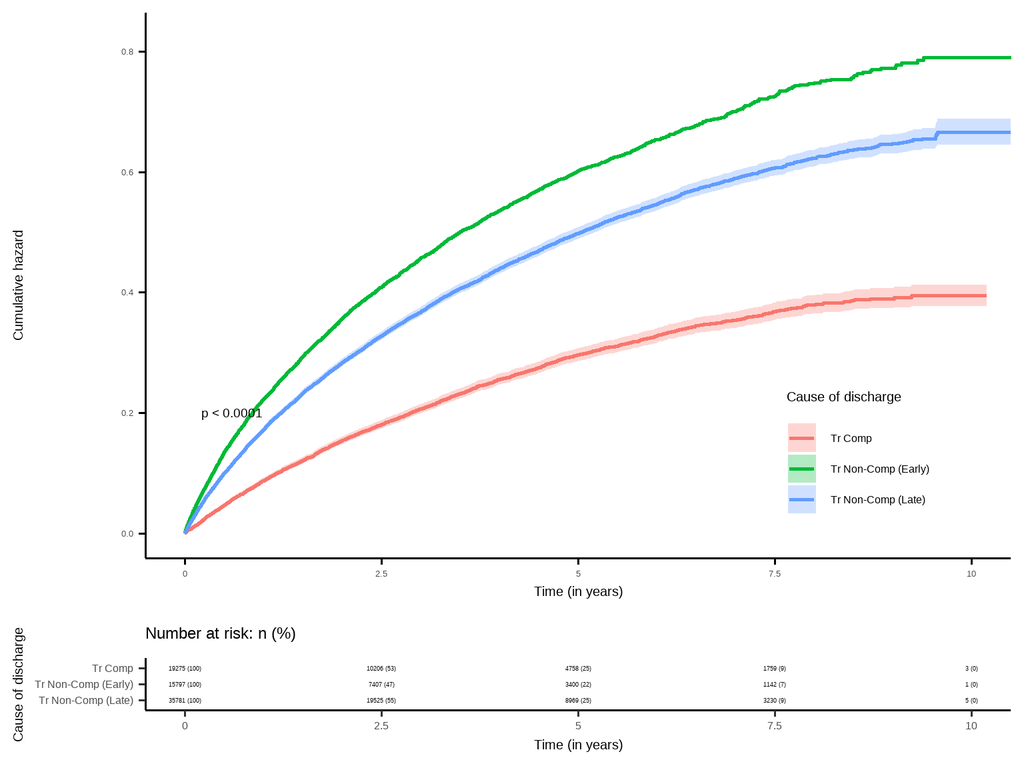

Figure 1: Difference with age of offense from discharge

```r
ggsurvplot(mot_egreso_fit,
           fun = "cumhaz",
           conf.int = TRUE,
           legend.labs = c("Tr Comp", "Tr Non-Comp (Early)", "Tr Non-Comp (Late)"),
           risk.table = "abs_pct",
           #ncensor.plot = TRUE,
           ggtheme = theme_classic2(base_size=15),
           risk.table.y.text.col = F,
           risk.table.col="black",
           font.tickslab = c(10),
           risk.table.height = .2,
           risk.table.fontsize = 2.5,
           #break.time.by = 365.25,
           pval = T,
           #ylim=c(0,10),
           legend = c(0.88, 0.2),
           legend.title="Cause of discharge",
           xlab= "Time (in years)",
           #cumevents=T,
           surv.connect = T,
           censor= F
           )
```

```r
#
```

Time for this code chunk to run: 0.3 minutes

We discarded cases with 1 relationships with a contact with the system before finishing treatment (imprisonment only)

**Difference with age of offense from discharge (imprisonment only)**

```r
mot_egreso_fit_pris<- survfit(Surv(age_offending_imp- edad_al_egres_imp,  !is.na(dateofbirth_imp)) ~motivodeegreso_mod_imp_rec, data=dplyr::filter(Base_fiscalia_v13_pris,age_offending_imp- edad_al_egres_imp>=0, motivodeegreso_mod_imp_rec!="Censored"),
                               type      = "kaplan-meier",
                                error     = "greenwood",
                                conf.type = "log-log")

mot_egreso_fit_na <- mot_egreso_fit_pris %>% fortify %>% group_by(strata) %>% mutate(CumHaz = cumsum(n.event/n.risk))
```

group_by: one grouping variable (strata)

mutate (grouped): new variable ‘CumHaz’ (double) with 5,139 unique values and 0% NA

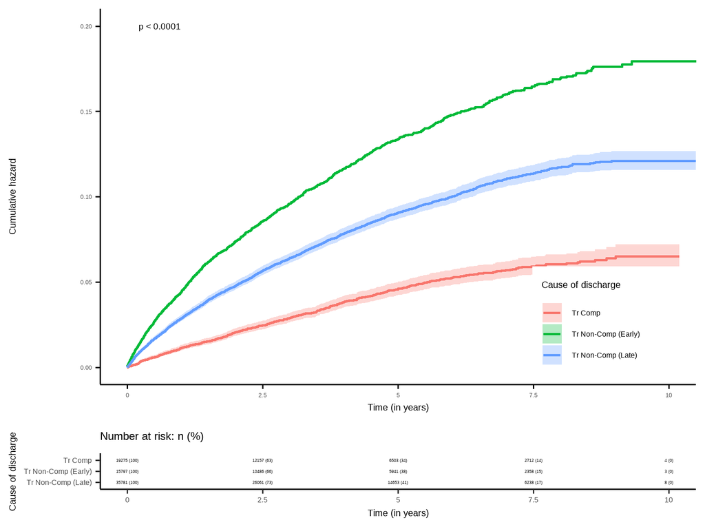

Figure 2: Difference with age of offense from discharge (imprisonment only)

```r
ggsurvplot(mot_egreso_fit_pris,
           fun = "cumhaz",
           conf.int = TRUE,
           legend.labs = c("Tr Comp", "Tr Non-Comp (Early)", "Tr Non-Comp (Late)"),
           risk.table = "abs_pct",
           #ncensor.plot = TRUE,
           ggtheme = theme_classic2(base_size=15),
           risk.table.y.text.col = F,
           risk.table.col="black",
           font.tickslab = c(10),
           risk.table.height = .2,
           risk.table.fontsize = 2.5,
           #break.time.by = 365.25,
           pval = T,
           #ylim=c(0,10),
           legend = c(0.88, 0.17),
           legend.title="Cause of discharge",
           xlab= "Time (in years)",
           #cumevents=T,
           surv.connect = T,
           censor= F
           )
```

```r
#
```

Time for this code chunk to run: 0.2 minutes

Given that our data has a staggered entry to the analysis (depending on the discharge)

**Survival of ages of offense from discharge (staggered entry)**

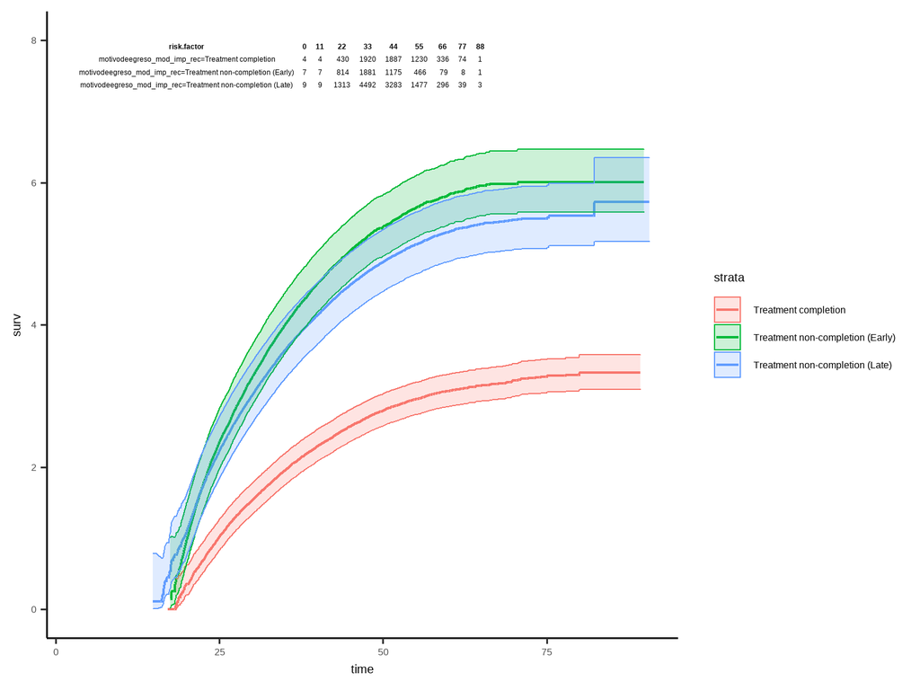

Figure 3: Difference with age of offense from discharge

```r
no_at_risk<-
survcomp::no.at.risk(formula.s=Surv(time2=age_offending_imp, time=edad_al_egres_imp,  !is.na(dateofbirth_imp)) ~motivodeegreso_mod_imp_rec, data.s=Base_fiscalia_v13,
  sub.s="all", t.step=round(min(Base_fiscalia_v13$edad_al_egres_imp)), t.end=round(max(Base_fiscalia_v13$age_offending_imp)))

mot_egreso_fit2<- survfit(Surv(time2=age_offending_imp, time=edad_al_egres_imp,  !is.na(dateofbirth_imp)) ~motivodeegreso_mod_imp_rec, data=dplyr::filter(Base_fiscalia_v13,age_offending_imp- edad_al_egres_imp>=0, motivodeegreso_mod_imp_rec!="Censored"),
                               type      = "fleming-harrington",
                                conf.type = "log-log")

fortify(mot_egreso_fit2, fun = "cumhaz") %>%
  data.frame() %>%
  ggplot(aes(x=time, y=surv, fill=strata, color=strata, group=strata))+
  geom_step(size=.8)+
  geom_ribbon(aes(ymin = lower, ymax = upper), alpha = .2) +
  theme_classic2(base_size=15)+
  annotate(geom = "table",
           x = 3,
           y = 8,
           label = list(no_at_risk),
           table.theme = ttheme_gtminimal)
```

Time for this code chunk to run: 0.2 minutes

**Survival of ages of offense from discharge (staggered entry) (imprisonment only)**

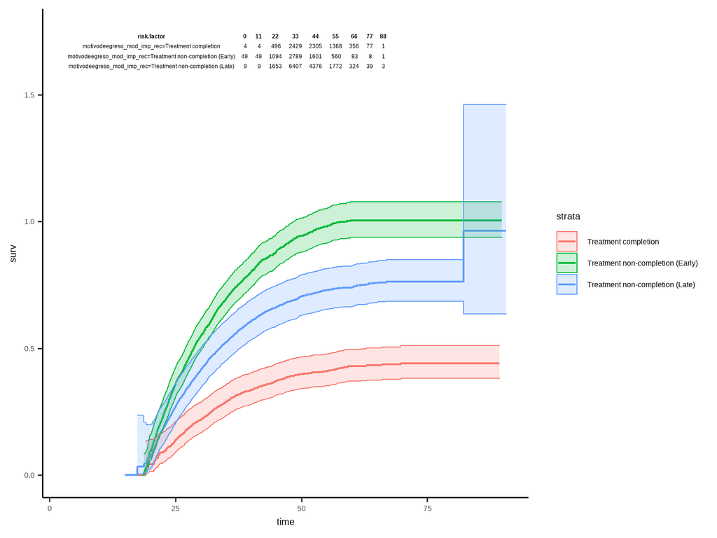

Figure 4: Difference with age of offense from discharge(imprisonment only)

```r
no_at_risk_pris<-
survcomp::no.at.risk(formula.s=Surv(time2=age_offending_imp, time=edad_al_egres_imp,  !is.na(dateofbirth_imp)) ~motivodeegreso_mod_imp_rec, data.s=Base_fiscalia_v13_pris,
  sub.s="all", t.step=round(min(Base_fiscalia_v13_pris$edad_al_egres_imp)), t.end=round(max(Base_fiscalia_v13_pris$age_offending_imp)))


mot_egreso_fit2_pris<- survfit(Surv(time2=age_offending_imp, time=edad_al_egres_imp,  !is.na(dateofbirth_imp)) ~motivodeegreso_mod_imp_rec, data=dplyr::filter(Base_fiscalia_v13_pris,age_offending_imp- edad_al_egres_imp>=0, motivodeegreso_mod_imp_rec!="Censored"),
                               type      = "fleming-harrington",
                                conf.type = "log-log")

fortify(mot_egreso_fit2_pris, fun = "cumhaz") %>%
  data.frame() %>%
  ggplot(aes(x=time, y=surv, fill=strata, color=strata, group=strata))+
  geom_step(size=.8)+
  geom_ribbon(aes(ymin = lower, ymax = upper), alpha = .2) +
  theme_classic2(base_size=15)+
  annotate(geom = "table",
           x = 3,
           y = 1.75,
           label = list(no_at_risk_pris),
           table.theme = ttheme_gtminimal)
```

Time for this code chunk to run: 0 minutes

```r
#https://rpubs.com/linpearl89/TTE-RCT
#https://search.r-project.org/CRAN/refmans/adjustedCurves/html/surv_aiptw_pseudo.html
#https://search.r-project.org/CRAN/refmans/adjustedCurves/html/surv_iptw_cox.html
#https://cran.r-project.org/web/packages/RISCA/RISCA.pdf

coxfit <- coxph(Surv(age_offending_imp- edad_al_egres_imp,  !is.na(dateofbirth_imp)) ~ motivodeegreso_mod_imp_rec + edad_al_ing_1 + edad_ini_cons + dias_treat_imp_sin_na_1 + escolaridad_rec + sus_principal_mod + freq_cons_sus_prin + compromiso_biopsicosocial + origen_ingreso_mod + numero_de_hijos_mod + tenencia_de_la_vivienda_mod + dg_cie_10_rec + dg_trs_cons_sus_or + macrozona + n_prev_off + n_off_vio + n_off_acq + n_off_sud + n_off_oth, ties="efron", data= Base_fiscalia_v13)

ggcoxdiagnostics(coxfit, type = "schoenfeld")
```

`geom_smooth()` using formula ‘y ~ x’

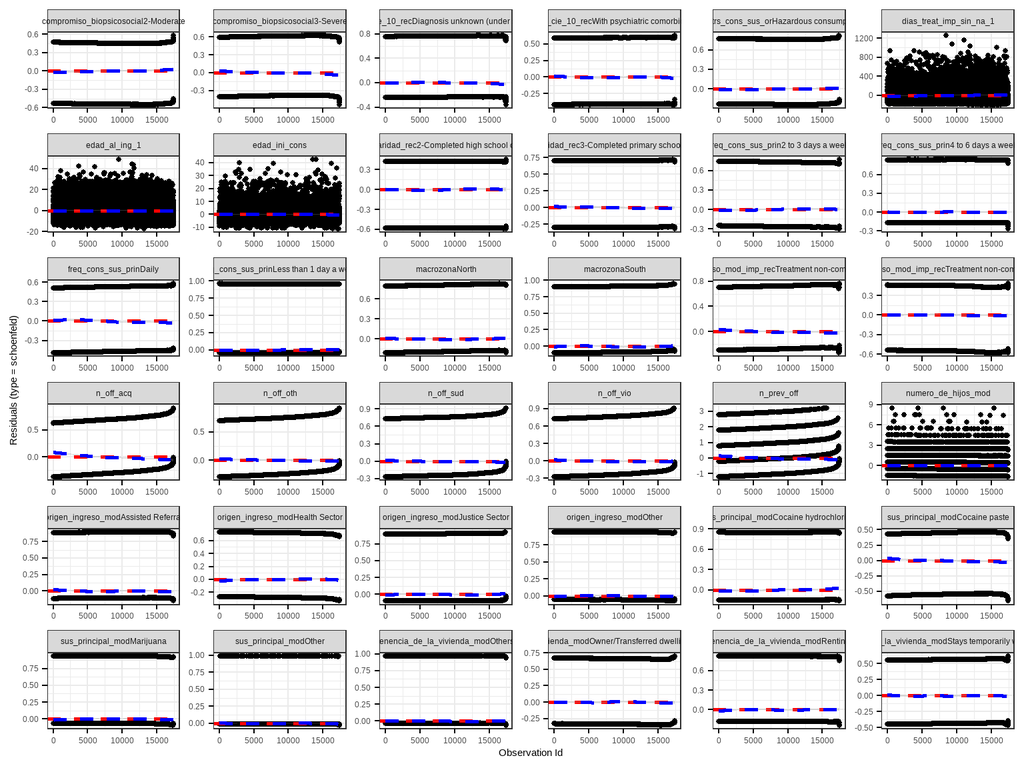

Figure 5: Schoefeld residuals

```r
ggsave("_figs/prueba.png", dpi=640, height=15, width= 15)
```

`geom_smooth()` using formula ‘y ~ x’

Time for this code chunk to run: 0.3 minutes

```r
#https://rpubs.com/linpearl89/TTE-RCT
#https://search.r-project.org/CRAN/refmans/adjustedCurves/html/surv_aiptw_pseudo.html
#https://search.r-project.org/CRAN/refmans/adjustedCurves/html/surv_iptw_cox.html
#https://cran.r-project.org/web/packages/RISCA/RISCA.pdf

coxfit2 <- coxph(Surv(edad_al_egres_imp,  age_offending_imp, !is.na(dateofbirth_imp)) ~ motivodeegreso_mod_imp_rec + edad_al_ing_1 + edad_ini_cons + dias_treat_imp_sin_na_1 + escolaridad_rec + sus_principal_mod + freq_cons_sus_prin + compromiso_biopsicosocial + origen_ingreso_mod + numero_de_hijos_mod + tenencia_de_la_vivienda_mod + dg_cie_10_rec + dg_trs_cons_sus_or + macrozona + n_prev_off + n_off_vio + n_off_acq + n_off_sud + n_off_oth, ties="efron", data= Base_fiscalia_v13)#[1:500,]

ggcoxdiagnostics(coxfit2, type = "schoenfeld")
```

`geom_smooth()` using formula ‘y ~ x’

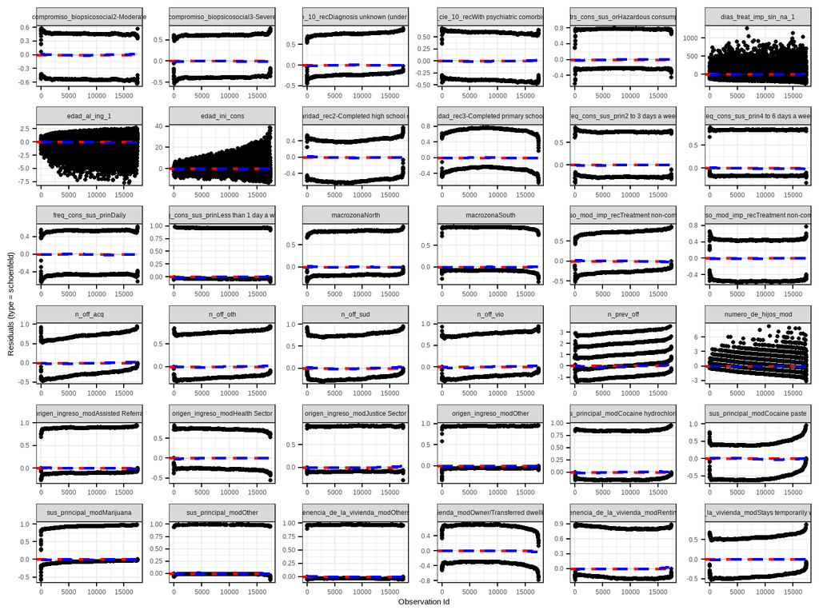

Figure 6: Schoefeld residuals (left censored)

```r
ggsave("_figs/prueba2.png", dpi=640, height=15, width= 15)
```

`geom_smooth()` using formula ‘y ~ x’

```r
warning(paste0("Number of users with age of offending lower than age at discharge: ", nrow(dplyr::filter(Base_fiscalia_v13,age_offending_imp<edad_al_egres_imp))))
```

Time for this code chunk to run: 0.3 minutes

```r
#https://rpubs.com/linpearl89/TTE-RCT
#https://search.r-project.org/CRAN/refmans/adjustedCurves/html/surv_aiptw_pseudo.html
#https://search.r-project.org/CRAN/refmans/adjustedCurves/html/surv_iptw_cox.html
#https://cran.r-project.org/web/packages/RISCA/RISCA.pdf

coxfit_pris <- coxph(Surv(age_offending_imp- edad_al_egres_imp,  !is.na(dateofbirth_imp)) ~ motivodeegreso_mod_imp_rec + edad_al_ing_1 + edad_ini_cons + dias_treat_imp_sin_na_1 + escolaridad_rec + sus_principal_mod + freq_cons_sus_prin + compromiso_biopsicosocial + origen_ingreso_mod + numero_de_hijos_mod + tenencia_de_la_vivienda_mod + dg_cie_10_rec + dg_trs_cons_sus_or + macrozona + n_prev_off + n_off_vio + n_off_acq + n_off_sud + n_off_oth, ties="efron", data= Base_fiscalia_v13_pris)#[1:250,]

ggcoxdiagnostics(coxfit_pris, type = "schoenfeld")
```

`geom_smooth()` using formula ‘y ~ x’

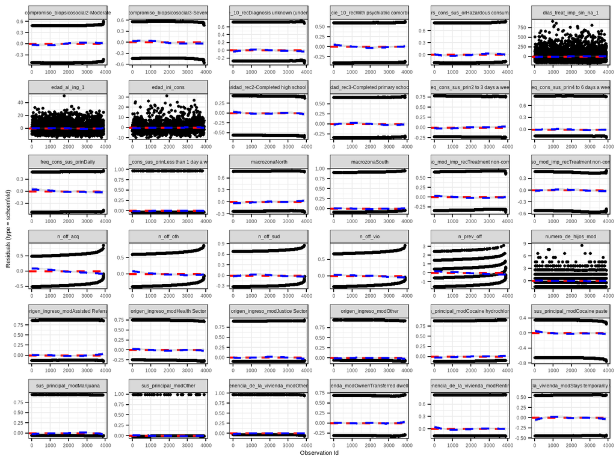

Figure 7: Schoefeld residuals (imprisonment only)

```r
ggsave("_figs/prueba_pris.png", dpi=640, height=15, width= 15)
```

`geom_smooth()` using formula ‘y ~ x’

Time for this code chunk to run: 0 minutes

```r
#https://rpubs.com/linpearl89/TTE-RCT
#https://search.r-project.org/CRAN/refmans/adjustedCurves/html/surv_aiptw_pseudo.html
#https://search.r-project.org/CRAN/refmans/adjustedCurves/html/surv_iptw_cox.html
#https://cran.r-project.org/web/packages/RISCA/RISCA.pdf

coxfit_pris2 <- coxph(Surv(edad_al_egres_imp,age_offending_imp,  !is.na(dateofbirth_imp)) ~ motivodeegreso_mod_imp_rec + edad_al_ing_1 + edad_ini_cons + dias_treat_imp_sin_na_1 + escolaridad_rec + sus_principal_mod + freq_cons_sus_prin + compromiso_biopsicosocial + origen_ingreso_mod + numero_de_hijos_mod + tenencia_de_la_vivienda_mod + dg_cie_10_rec + dg_trs_cons_sus_or + macrozona + n_prev_off + n_off_vio + n_off_acq + n_off_sud + n_off_oth, ties="efron", data= Base_fiscalia_v13_pris)#[1:250,]

ggcoxdiagnostics(coxfit_pris2, type = "schoenfeld")
```

`geom_smooth()` using formula ‘y ~ x’

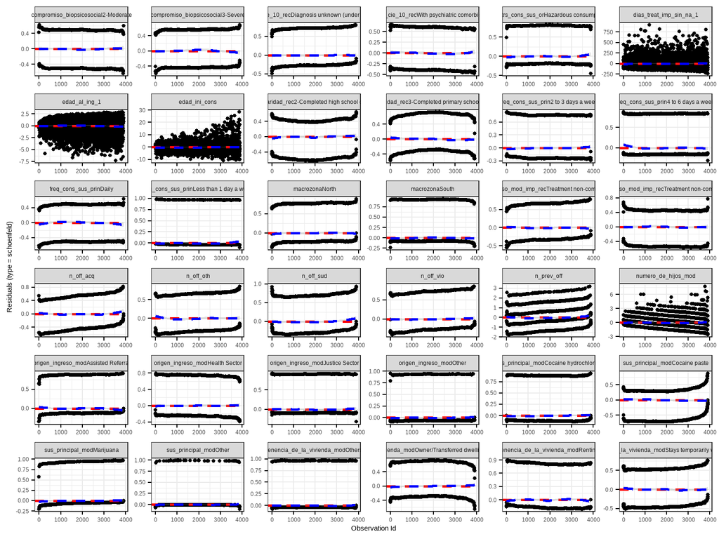

Figure 8: Schoefeld residuals (left censored, imprisonment only)

```r
ggsave("_figs/prueba_pris2.png", dpi=640, height=15, width= 15)
```

`geom_smooth()` using formula ‘y ~ x’

```r
warning(paste0("Number of users with age of offending lower than age at discharge: ", nrow(dplyr::filter(Base_fiscalia_v13_pris,age_offending_imp<edad_al_egres_imp))))
```

Time for this code chunk to run: 1 minutes

## Commentary

```r
invisible("1.Aberrant ages")
errors_age_after_join<-
Base_fiscalia_v13 %>%
  dplyr::filter(edad_al_egres_imp<=14|edad_al_egres_imp>=80|age_offending_imp<=14|age_offending_imp>=80)

errors_age_after_join_pris<-
Base_fiscalia_v13_pris %>%
  dplyr::filter(edad_al_egres_imp<=14|edad_al_egres_imp>=80|age_offending_imp<=14|age_offending_imp>=80)
  #dplyr::filter(hash_key %in% errores_edad)
```

Time for this code chunk to run: 0 minutes

28 patients being discharged at 14 years of age or less, or at 80 years of age or more

73 patients that offended and ended with prison at 14 years of age or less, or at 80 years of age or more In total, these cases represent the 0.11% of the database.

28 patients being discharged at 14 years of age or less, or at 80 years of age or more

75 patients that offended and ended with prison at 14 years of age or less, or at 80 years of age or more In total, these cases represent the 0.12% of the database.

```r
#_#_#_#_#_#_#_#_#_
invisible("2.Explore RUCs")

paste0("Number of unique RUCs: ", length(unique(Base_fiscalia_v13$caseid)), " of ", length(Base_fiscalia_v13$caseid)," rows")
```

```
[1] "Number of unique RUCs: 22228 of 70863 rows"
```

```r
paste0("Number of unique RUCs (imprisonment): ", length(unique(Base_fiscalia_v13_pris$caseid)), " of ", length(Base_fiscalia_v13_pris$caseid)," rows")
```

```
[1] "Number of unique RUCs (imprisonment): 5124 of 70863 rows"
```

```r
warning(paste0("Records that share a RUC n= ",
Base_fiscalia_v13 %>%
    dplyr::ungroup() %>%
    dplyr::group_by(caseid) %>%
    dplyr::mutate(dis_rut=n_distinct(hash_key)) %>%
    dplyr::ungroup() %>%
    #filter people that was not paired but keep people with more than one RUC
    dplyr::filter(dis_rut>1,dis_rut<5000) %>% nrow()
))


warning(paste0("Records that share a RUC (imprisonment) n= ",
Base_fiscalia_v13_pris %>%
    dplyr::ungroup() %>%
    dplyr::group_by(caseid) %>%
    dplyr::mutate(dis_rut=n_distinct(hash_key)) %>%
    dplyr::ungroup() %>%
    #filter people that was not paired but keep people with more than one RUC
    dplyr::filter(dis_rut>1,dis_rut<5000) %>% nrow()
))

Base_fiscalia_v13 %>%
  dplyr::ungroup() %>%
  dplyr::group_by(caseid) %>%
  dplyr::mutate(dis_rut=n_distinct(hash_key)) %>%
  dplyr::ungroup() %>%
  #filter people that was not paired but keep people with more than one RUC
  dplyr::filter(dis_rut<5000) %>%
   dplyr::summarise(total= n(),max= max(dis_rut), min= min(dis_rut), mean=round(mean(dis_rut),2), p025= quantile(dis_rut, .025), p25= quantile(dis_rut, .25), median= quantile(dis_rut, .5), p75= quantile(dis_rut, .75), p975= quantile(dis_rut, .975)) %>%
knitr::kable("markdown", caption="Summary descriptives, distinct IDs by Case ID")
```

Table 9: Summary descriptives, distinct IDs by Case ID

| total | max | min | mean | p025 | p25 | median | p75 | p975 |
| --- | --- | --- | --- | --- | --- | --- | --- | --- |
| 22287 | 3 | 1 | 1.01 | 1 | 1 | 1 | 1 | 1 |

```r
#table(Base_fiscalia_v13$caseid) %>% data.frame() %>%  arrange(-Freq) %>% slice(1:10)
#table(Base_fiscalia_v13_pris$caseid) %>% data.frame() %>%  arrange(-Freq) %>% slice(1:10)

Base_fiscalia_v13_pris %>%
  dplyr::ungroup() %>%
  dplyr::group_by(caseid) %>%
  dplyr::mutate(dis_rut=n_distinct(hash_key)) %>%
  dplyr::ungroup() %>%
  #filter people that was not paired but keep people with more than one RUC
  dplyr::filter(dis_rut<5000) %>%
   dplyr::summarise(total= n(),max= max(dis_rut), min= min(dis_rut), mean=round(mean(dis_rut),2), p025= quantile(dis_rut, .025), p25= quantile(dis_rut, .25), median= quantile(dis_rut, .5), p75= quantile(dis_rut, .75), p975= quantile(dis_rut, .975)) %>%
knitr::kable("markdown", caption="Summary descriptives, distinct IDs by Case ID (Imprisonment)")
```

Table 9: Summary descriptives, distinct IDs by Case ID (Imprisonment)

| total | max | min | mean | p025 | p25 | median | p75 | p975 |
| --- | --- | --- | --- | --- | --- | --- | --- | --- |
| 5144 | 2 | 1 | 1.01 | 1 | 1 | 1 | 1 | 1 |

Time for this code chunk to run: 0.1 minutes

```r
#If the value of VIF is less than 1: no correlation - If the value of VIF is between 1-5, there is moderate correlation - If the value of VIF is above 5: severe correlation

#_#_#_#_#_#_#_#_#_
invisible("3.Cox, collinearity")
#global covs_3 "i.caus_disch_mod_imp_rec edad_al_ing_1 edad_ini_cons i.sex_enc i.esc_rec i.sus_prin_mod i.fr_sus_prin i.comp_biosoc i.ten_viv i.dg_cie_10_rec i.sud_severity_icd10 i.macrozone i.policonsumo i.n_off_vio i.n_off_acq i.n_off_sud "

library(rms)

f1 <- cph(Surv(age_offending_imp- edad_al_egres_imp,  !is.na(dateofbirth_imp)) ~ motivodeegreso_mod_imp_rec + edad_al_ing_1 + edad_ini_cons + escolaridad_rec + sus_principal_mod + freq_cons_sus_prin + compromiso_biopsicosocial + origen_ingreso_mod + numero_de_hijos_mod + tenencia_de_la_vivienda_mod + dg_cie_10_rec + dg_trs_cons_sus_or + macrozona + n_prev_off + n_off_vio + n_off_acq + n_off_sud, data= Base_fiscalia_v13, x=T, y=T)
warning("X matrix deemed to be singular; variable n_off_oth")

cvif <- rms::vif(f1)

f2 <- cph(Surv(edad_al_egres_imp,age_offending_imp,  !is.na(dateofbirth_imp)) ~ motivodeegreso_mod_imp_rec + edad_al_ing_1 + edad_ini_cons + escolaridad_rec + sus_principal_mod + freq_cons_sus_prin + compromiso_biopsicosocial + origen_ingreso_mod + numero_de_hijos_mod + tenencia_de_la_vivienda_mod + dg_cie_10_rec + dg_trs_cons_sus_or + macrozona + n_prev_off + n_off_vio + n_off_acq + n_off_sud, data= Base_fiscalia_v13, x=T, y=T)
warning("X matrix deemed to be singular; variable n_off_oth")

cvif2 <- rms::vif(f2)


f3 <- cph(Surv(age_offending_imp- edad_al_egres_imp,  !is.na(dateofbirth_imp)) ~ motivodeegreso_mod_imp_rec + edad_al_ing_1 + edad_ini_cons + escolaridad_rec + sus_principal_mod + freq_cons_sus_prin + compromiso_biopsicosocial + origen_ingreso_mod + numero_de_hijos_mod + tenencia_de_la_vivienda_mod + dg_cie_10_rec + dg_trs_cons_sus_or + macrozona + n_prev_off + n_off_vio + n_off_acq + n_off_sud, data= Base_fiscalia_v13, x=T, y=T)
warning("X matrix deemed to be singular; variable n_off_oth")

cvif3 <- rms::vif(f3)

f4 <- cph(Surv(edad_al_egres_imp,age_offending_imp,  !is.na(dateofbirth_imp)) ~ motivodeegreso_mod_imp_rec + edad_al_ing_1 + edad_ini_cons + escolaridad_rec + sus_principal_mod + freq_cons_sus_prin + compromiso_biopsicosocial + origen_ingreso_mod + numero_de_hijos_mod + tenencia_de_la_vivienda_mod + dg_cie_10_rec + dg_trs_cons_sus_or + macrozona + n_prev_off + n_off_vio + n_off_acq + n_off_sud, data= Base_fiscalia_v13, x=T, y=T)
warning("X matrix deemed to be singular; variable n_off_oth")

cvif4 <- rms::vif(f4)

cbind.data.frame(Time0_cond_sent=cvif,
                 Time0_prison=cvif2,
                 Stag_ent_cond_sent=cvif3,
                 Stag_ent_prison=cvif4) %>%
  knitr::kable("markdown", caption= "Variance Inflation Factors in Cox Regressions")
```

Table 10: Variance Inflation Factors in Cox Regressions

|  | Time0_cond_sent | Time0_prison | Stag_ent_cond_sent | Stag_ent_prison |
| --- | --- | --- | --- | --- |
| motivodeegreso_mod_imp_rec=Treatment non-completion (Early) | 2.634636 | 2.629710 | 2.634636 | 2.629710 |
| motivodeegreso_mod_imp_rec=Treatment non-completion (Late) | 1.990506 | 1.995766 | 1.990506 | 1.995766 |
| edad_al_ing_1 | 1.484788 | 1.055109 | 1.484788 | 1.055109 |
| edad_ini_cons | 1.124585 | 1.033351 | 1.124585 | 1.033351 |
| escolaridad_rec=2-Completed high school or less | 2.439260 | 2.429669 | 2.439260 | 2.429669 |
| escolaridad_rec=3-Completed primary school or less | 2.542093 | 2.547284 | 2.542093 | 2.547284 |
| sus_principal_mod=Cocaine hydrochloride | 1.636192 | 1.628972 | 1.636192 | 1.628972 |
| sus_principal_mod=Cocaine paste | 2.108405 | 2.023687 | 2.108405 | 2.023687 |
| sus_principal_mod=Marijuana | 1.355469 | 1.327040 | 1.355469 | 1.327040 |
| sus_principal_mod=Other | 1.066803 | 1.063514 | 1.066803 | 1.063514 |
| freq_cons_sus_prin=2 to 3 days a week | 4.425791 | 4.424106 | 4.425791 | 4.424106 |
| freq_cons_sus_prin=4 to 6 days a week | 3.550331 | 3.551365 | 3.550331 | 3.551365 |
| freq_cons_sus_prin=Daily | 5.637188 | 5.635209 | 5.637188 | 5.635209 |
| freq_cons_sus_prin=Less than 1 day a week | 1.706850 | 1.706286 | 1.706850 | 1.706286 |
| compromiso_biopsicosocial=2-Moderate | 4.421635 | 4.422421 | 4.421635 | 4.422421 |
| compromiso_biopsicosocial=3-Severe | 4.997654 | 4.994702 | 4.997654 | 4.994702 |
| origen_ingreso_mod=Assisted Referral | 1.144456 | 1.143399 | 1.144456 | 1.143399 |
| origen_ingreso_mod=Other | 1.073975 | 1.074255 | 1.073975 | 1.074255 |
| origen_ingreso_mod=Justice Sector | 1.163981 | 1.164338 | 1.163981 | 1.164338 |
| origen_ingreso_mod=Health Sector | 1.241118 | 1.239130 | 1.241118 | 1.239130 |
| numero_de_hijos_mod | 1.247618 | 1.066145 | 1.247618 | 1.066145 |
| tenencia_de_la_vivienda_mod=Others | 3.282532 | 3.282658 | 3.282532 | 3.282658 |
| tenencia_de_la_vivienda_mod=Owner/Transferred dwellings/Pays Dividends | 16.674641 | 16.468594 | 16.674641 | 16.468594 |
| tenencia_de_la_vivienda_mod=Renting | 11.414787 | 11.370582 | 11.414787 | 11.370582 |
| tenencia_de_la_vivienda_mod=Stays temporarily with a relative | 18.176758 | 17.896228 | 18.176758 | 17.896228 |
| dg_cie_10_rec=Diagnosis unknown (under study) | 1.825530 | 1.800481 | 1.825530 | 1.800481 |
| dg_cie_10_rec=With psychiatric comorbidity | 1.330415 | 1.327856 | 1.330415 | 1.327856 |
| dg_trs_cons_sus_or=Hazardous consumption | 1.195688 | 1.196558 | 1.195688 | 1.196558 |
| macrozona=North | 1.128861 | 1.130843 | 1.128861 | 1.130843 |
| macrozona=South | 1.132089 | 1.127430 | 1.132089 | 1.127430 |
| n_prev_off | 6.910131 | 6.774116 | 6.910131 | 6.774116 |
| n_off_vio | 2.625894 | 2.612706 | 2.625894 | 2.612706 |
| n_off_acq | 2.827617 | 2.767498 | 2.827617 | 2.767498 |
| n_off_sud | 2.381478 | 2.362247 | 2.381478 | 2.362247 |

```r
    # dplyr::mutate_if(is.numeric,~round(.,2)) %>%
    # DT::datatable()
```

Time for this code chunk to run: 0.1 minutes

The Total number of previous offenses showed a severe correlation (VIF >6.5), and Housing situation (tenure status of households) (VIF > 11). Must consider that the biopsychosocial compromise and Substance use frequency (primary substance) had a moderate correlation (~5 VIF).

```r
#_#_#_#_#_#_#_#_#_
invisible("4.Why there are more patients in prison database than contacts with sentence data base?")
#unique(Base_fiscalia_v13_pris$hash_key)
#unique(Base_fiscalia_v13$hash_key)

warning(paste0("Patients that are registered in the sentence database but not in the prison data base: ",

Base_fiscalia_v13 %>%
  dplyr::filter(!hash_key %in% unique(Base_fiscalia_v13_pris$hash_key)) %>% nrow()
))

warning(paste0("Patients that are registered in the prison database but not in the sentence data base: ",
Base_fiscalia_v13_pris %>%
  dplyr::filter(!hash_key %in% unique(Base_fiscalia_v13$hash_key)) %>% nrow()
))

hash_key_non_sentence_but_pris<-
Base_fiscalia_v12_pris %>%
  dplyr::filter(!hash_key %in% unique(Base_fiscalia_v13$hash_key)) %>% distinct(hash_key) %>% unlist(as.character())
```

distinct: no rows removed

```r
#23d88c2b8c6da2d8abf3f88b7ce8a4c0
#In case of the patient above, when he was matched with the requirements of prison (wich is more stringent), it allowed that 2 treatments were elligible to match: one in 2011-01-06 to 2011-02-28 and another in 2011-12-05 to 2012-03-05. The problem is that we wanted to match with baseline treatments, hence prison skips the first treatment that ended in a referral and ended matching with the second. At 2022-11-25 I ended correcting it.
```

Time for this code chunk to run: 0 minutes

```r
# stipw (logit motivodeegreso_mod_imp_rec2 edad_al_ing_1 edad_ini_cons sex_enc esc_rec sus_prin_mod fr_sus_prin comp_biosoc ten_viv dg_cie_10_rec sud_severity_icd10 macrozone policonsumo n_off_vio n_off_acq n_off_sud clas), distribution(rp) df(10) ipwtype(stabilised) vce(mestimation) eform
# estimates store df10_stipw

f4 <- cph(Surv(edad_al_egres_imp,age_offending_imp,  !is.na(dateofbirth_imp)) ~ motivodeegreso_mod_imp_rec + edad_al_ing_1 + edad_ini_cons + sex+ escolaridad_rec + sus_principal_mod + freq_cons_sus_prin + compromiso_biopsicosocial + tenencia_de_la_vivienda_mod + dg_cie_10_rec + dg_trs_cons_sus_or + macrozona + policonsumo + n_off_vio + n_off_acq + n_off_sud, data= Base_fiscalia_v13, x=T, y=T) #origen_ingreso_mod + numero_de_hijos_mod +  = no estaban en Stata
# falta clas
```

Time for this code chunk to run: 0 minutes

# Flowchart

```r
if(isTRUE(getOption('knitr.in.progress'))==T){
} else {
  #path<-ifelse(!grepl("$\\/",getwd()),paste0(getwd(),"/"),getwd())
  path<- getwd()
}
```

```r
tab1_lab_aft_d<- paste0('Original C1 Dataset \n(n = ', formatC(nrow(CONS_C1), format='f', big.mark=',', digits=0), ';\npatients: ',formatC(CONS_C1%>% dplyr::distinct(HASH_KEY)%>% nrow(), format='f', big.mark=',', digits=0),')')
tab2_lab_aft_d<- paste0('&#8226;Remove duplicated entries\\\\\\l&#8226;Overlapping treatments of patients\\\\\\l&#8226;Intermediate treatment events (continuous referrals)    \\\\\\l')
tab3_lab_aft_d<- paste0('      C1 Dataset          \n(n = ', formatC(nrow(CONS_C1_df_dup_SEP_2020), format='f', big.mark=',', digits=0), ';\npatients: ',formatC(CONS_C1_df_dup_SEP_2020%>% dplyr::distinct(hash_key)%>% nrow(), format='f', big.mark=',', digits=0),')')
tab4_lab_aft_d<- paste0('Original Prosecutors Office\n(n = ',format(nrow(Base_fiscalia_v2),big.mark=","),
                        ';\nCauses= ',Base_fiscalia_v2%>% dplyr::distinct(ruc)%>% nrow() %>% format(big.mark=','),
                        ';\nRel.=',Base_fiscalia_v2%>%dplyr::distinct(idrelacion)%>%nrow()%>%format(big.mark=','),
                        ';\nRUC_Vic_Imp=',Base_fiscalia_v2%>%dplyr::mutate(rel=paste0(ruc,"_",idsujeto_victima,"_",idsujeto_imputado,"_","iddelito"))%>%dplyr::distinct(rel)%>%nrow()%>%format(big.mark=','),
                        ';\nindividuals= ',Base_fiscalia_v2%>% dplyr::distinct(rut_enc_saf)%>% nrow() %>% format(big.mark=','),')')

#crimes committed after study follow-up
tab5_lab_aft_d1<-
    paste0("(p= ",format(nrow(unique(subset(Base_fiscalia_v2,fec_comision_simple>as.Date("2019-11-13"),"rut_enc_saf"))),big.mark=","),"; RUCs= ",
           format(nrow(unique(subset(Base_fiscalia_v2,fec_comision_simple>as.Date("2019-11-13"),"ruc"))), big.mark=","),";n= ",
           format(nrow(subset(Base_fiscalia_v2,fec_comision_simple>as.Date("2019-11-13"),"rut_enc_saf")), big.mark=","),")")
#erase entries with missing values in fec_comision_simple y termino_relacion_simple
leftovers_Base_fiscalia_v3<-
Base_fiscalia_v3 %>%
  dplyr::left_join(after_imp_Base_fiscalia_v3_db[,c("rut_enc_saf","imp_birth_date","flowch_age")], by="rut_enc_saf") %>%
  dplyr::rename("obs"="flowch_age") %>%
  dplyr::mutate(imp_birth_date=dplyr::case_when(!is.na(imp_birth_date)~imp_birth_date,T~fec_nacimiento_simple))%>% dplyr::mutate(edad_comision_imp=as.numeric(fec_comision_simple-imp_birth_date)/365.25) %>% dplyr::mutate(edad_ter_rel_imp=as.numeric(termino_relacion_simple-imp_birth_date)/365.25) %>%
  #arrange the rut from the first date of comission of a crime, but we are not detecting if he/she is the victim or not
  dplyr::arrange(rut_enc_saf, edad_comision_imp) %>% #566884
  dplyr::filter(dplyr::case_when(!is.na(edad_comision_imp)~T,T~F)) %>% #566644
  dplyr::filter(imp_birth_date=="1900-01-01"|is.na(imp_birth_date))

tab5_lab_aft_d12<-
    paste0("(p= ",format(nrow(dplyr::distinct(leftovers_Base_fiscalia_v3,rut_enc_saf)),big.mark=","),"; RUCs= ",
           format(nrow(dplyr::distinct(leftovers_Base_fiscalia_v3,ruc)), big.mark=","),";n= ",
           format(nrow(leftovers_Base_fiscalia_v3), big.mark=","),")")

#minor to 14 years old
tab5_lab_aft_d13<-
    paste0("(p= ",format(nrow(dplyr::distinct(dplyr::filter(Base_fiscalia_v4,edad_comision_imp<14),rut_enc_saf)),big.mark=","),"; RUCs= ",
           format(nrow(dplyr::distinct(dplyr::filter(Base_fiscalia_v4,edad_comision_imp<14),ruc)), big.mark=","),";n= ",
           format(nrow(dplyr::filter(Base_fiscalia_v4,edad_comision_imp<14)), big.mark=","),")")

#Remove duplicated entries
tab5_lab_aft_d2<-
  paste0("(p= ",format(length(unique(eliminated_duplicates$rut_enc_saf)),big.mark=","),"; RUCs= ",
           format(length(unique(eliminated_duplicates$ruc)), big.mark=","),";n= ",
           format(nrow(eliminated_duplicates), big.mark=","),")")
#before 2010
 tab5_lab_aft_d3<-
    paste0("(p= ",format(nrow(dplyr::distinct(dplyr::filter(Base_fiscalia_v7,fec_comision_simple<"2010-01-01"),rut_enc_saf)),big.mark=","),"; RUCs= ",
           format(nrow(dplyr::distinct(dplyr::filter(Base_fiscalia_v7,fec_comision_simple<"2010-01-01"),ruc)), big.mark=","),";n= ",
           format(nrow(dplyr::filter(Base_fiscalia_v7,fec_comision_simple<"2010-01-01")), big.mark=","),")")
#remove administrative annulment
tab5_lab_aft_d4<-
    paste0("(p= ",format(nrow(dplyr::distinct(dplyr::filter(Base_fiscalia_v7,agrupa_terminos=="ANULACI¿N ADMINISTRATIVA"),rut_enc_saf)),big.mark=","),"; RUCs= ",
           format(nrow(dplyr::distinct(dplyr::filter(Base_fiscalia_v7,agrupa_terminos=="ANULACI¿N ADMINISTRATIVA"),ruc)), big.mark=","),";n= ",
           format(nrow(dplyr::filter(Base_fiscalia_v7,agrupa_terminos=="ANULACI¿N ADMINISTRATIVA")), big.mark=","),")")
#remove grouped to another case
tab5_lab_aft_d5<-
    paste0("(p= ",format(nrow(dplyr::distinct(dplyr::filter(Base_fiscalia_v7,agrupa_terminos=="AGRUPACI¿N A OTRO CASO"),rut_enc_saf)),big.mark=","),"; RUCs= ",
           format(nrow(dplyr::distinct(dplyr::filter(Base_fiscalia_v7,agrupa_terminos=="AGRUPACI¿N A OTRO CASO"),ruc)), big.mark=","),";n= ",
           format(nrow(dplyr::filter(Base_fiscalia_v7,agrupa_terminos=="AGRUPACI¿N A OTRO CASO")), big.mark=","),")")

tab5_lab_aft_d<- paste0('&#8226;Filter crimes committed after study follow-up period',tab5_lab_aft_d1,'\\\\\\l&#8226;Remove duplicated entries',tab5_lab_aft_d2,'\\\\\\l&#8226;Correct dates (birth, comission of crime, end of judicial proceedings), missing nationality and sex\\\\\\l&#8226;Erase entries with missing values in  comission of crime, end of judicial proceedings',tab5_lab_aft_d12,'\\\\\\l&#8226;Erase entries with values in comission of crime when minor to 14 years old after imputation',tab5_lab_aft_d13,'\\\\\\l&#8226;Filter crimes committed before study follow-up',tab5_lab_aft_d3,'\\\\\\l&#8226;Filter records with cause of end of the proceedings= administrative annulment',tab5_lab_aft_d4,'\\\\\\l&#8226;Filter records with cause of end of the proceedings= grouped to another case',tab5_lab_aft_d5,'\\\\\\l')
tab6_lab_aft_d<- paste0("O.P. Dataset \n(n= ", formatC(nrow(Base_fiscalia_v8),big.mark = ","),";\nindividuals= ",Base_fiscalia_v8%>% dplyr::distinct(rut_enc_saf)%>% nrow()%>% formatC(big.mark = ","),")")
```

```r
#not coded as an offender
tab7_lab_aft_d1<-
    paste0("(p= ",format(nrow(dplyr::distinct(dplyr::filter(Base_fiscalia_v8,!grepl("SI",encontrado_como_imputado)),rut_enc_saf)),big.mark=","),"; RUCs= ",
           format(nrow(dplyr::distinct(dplyr::filter(Base_fiscalia_v8,!grepl("SI",encontrado_como_imputado)),ruc)), big.mark=","),";n= ",
           format(nrow(dplyr::filter(Base_fiscalia_v8,!grepl("SI",encontrado_como_imputado))), big.mark=","),")")

#FILTER IF THE PATIENT RECIEVES FOR THE RELATIONSHIP AMONG THOSE THAT WERE OFFENDERS
# end of proceeding
tab7_lab_aft_d2<-
      paste0("(p= ",format(nrow(dplyr::distinct(dplyr::filter(Base_fiscalia_v8,grepl("SI",encontrado_como_imputado)) %>% dplyr::filter(dplyr::case_when( grepl("REPARATORIO|CONDICIONAL",gls_mottermino) & is.na(agrupa_terminos)~F, grepl("REPARATORIO|SENTENCIA DEFINITIVA CONDENATORIA|240|MONIT", toupper(agrupa_terminos), ignore.case=F)~F, T~T)),rut_enc_saf)),big.mark=","),"; RUCs= ",
           format(nrow(dplyr::distinct(dplyr::filter(Base_fiscalia_v8,grepl("SI",encontrado_como_imputado)) %>% dplyr::filter(dplyr::case_when( grepl("REPARATORIO|CONDICIONAL",gls_mottermino) & is.na(agrupa_terminos)~F, grepl("REPARATORIO|SENTENCIA DEFINITIVA CONDENATORIA|240|MONIT", toupper(agrupa_terminos), ignore.case=F)~F, T~T)),ruc)), big.mark=","),";n= ",
           format(nrow(dplyr::filter(Base_fiscalia_v8,grepl("SI",encontrado_como_imputado)) %>% dplyr::filter(dplyr::case_when( grepl("REPARATORIO|CONDICIONAL",gls_mottermino) & is.na(agrupa_terminos)~F, grepl("REPARATORIO|SENTENCIA DEFINITIVA CONDENATORIA|240|MONIT", toupper(agrupa_terminos), ignore.case=F)~F, T~T))), big.mark=","),")")

#FILTER USERS WITHOUT BIRTH DATE AFTER JOIN (7)
tab7_lab_aft_d3<-
    paste0("(p= ",format(nrow(dplyr::distinct(dplyr::filter(janitor::clean_names(Base_fiscalia_v10),is.na(fech_nac_rec)),hash_key)),big.mark=","),"; RUCs= ",
           format(nrow(dplyr::distinct(dplyr::filter(janitor::clean_names(Base_fiscalia_v10),is.na(fech_nac_rec)),caseid)), big.mark=","), "(had no case ID)",";n= ",
           format(nrow(dplyr::filter(janitor::clean_names(Base_fiscalia_v10),is.na(fech_nac_rec))), big.mark=","),")")

#FILTER USERS THAT HAD AN ONGOING TREATMENT
tab7_lab_aft_d4<-
paste0("(p= ",format(nrow(dplyr::distinct(dplyr::filter(Base_fiscalia_v11, grepl("Referral|Death|Censored|Ongoing",motivodeegreso_mod_imp)),hash_key)),big.mark=","),"; RUCs= ",
           format(nrow(dplyr::distinct(dplyr::filter(Base_fiscalia_v11, grepl("Referral|Death|Censored|Ongoing",motivodeegreso_mod_imp)),caseid)), big.mark=","),";n= ",
           format(nrow(dplyr::filter(Base_fiscalia_v11, grepl("Referral|Death|Censored|Ongoing",motivodeegreso_mod_imp))), big.mark=","),")")


tab7_lab_aft_d<- paste0('&#8226;Discard observations coded as victims rather than ofenders ',tab7_lab_aft_d1,'\\\\\\l&#8226;Discard observations depending on the values of the end of the proceedings among offenders',tab7_lab_aft_d2,'          \\\\\\l&#8226;Discard observations without birth date ',tab7_lab_aft_d3,'\\\\\\l&#8226;Discard observations coded as referrals, deaths, censored at baseline treatment or with ongoing treatments ',tab7_lab_aft_d4,'         \\\\\\l&#8226;Long-to-wide relationships/crimes, end of judicial proceedings, penalty         \\\\\\l&#8226;Group crimes into violent, drug-related, etc.         \\\\\\l')

#not coded as an offender
tab7b_lab_aft_d1<-
    paste0("(p= ",format(nrow(dplyr::distinct(dplyr::filter(Base_fiscalia_v8,!grepl("SI",encontrado_como_imputado)),rut_enc_saf)),big.mark=","),"; RUCs= ",
           format(nrow(dplyr::distinct(dplyr::filter(Base_fiscalia_v8,!grepl("SI",encontrado_como_imputado)),ruc)), big.mark=","),";n= ",
           format(nrow(dplyr::filter(Base_fiscalia_v8,!grepl("SI",encontrado_como_imputado))), big.mark=","),")")

#FILTER IF THE PATIENT RECIEVES FOR THE RELATIONSHIP AMONG THOSE THAT WERE OFFENDERS
# end of proceeding
tab7b_lab_aft_d2<-
     paste0("(p= ",format(nrow(dplyr::distinct(dplyr::filter(Base_fiscalia_v8,grepl("SI",encontrado_como_imputado)) %>% dplyr::filter(dplyr::case_when( grepl("REPARATORIO|CONDICIONAL",gls_mottermino) & is.na(agrupa_terminos)~F, grepl("REPARATORIO|SENTENCIA DEFINITIVA CONDENATORIA|240|MONIT", toupper(agrupa_terminos), ignore.case=F)~F, T~T)),rut_enc_saf)),big.mark=","),"; RUCs= ",
           format(nrow(dplyr::distinct(dplyr::filter(Base_fiscalia_v8,grepl("SI",encontrado_como_imputado)) %>% dplyr::filter(dplyr::case_when( grepl("REPARATORIO|CONDICIONAL",gls_mottermino) & is.na(agrupa_terminos)~F, grepl("REPARATORIO|SENTENCIA DEFINITIVA CONDENATORIA|240|MONIT", toupper(agrupa_terminos), ignore.case=F)~F, T~T)),ruc)), big.mark=","),";n= ",
           format(nrow(dplyr::filter(Base_fiscalia_v8,grepl("SI",encontrado_como_imputado)) %>% dplyr::filter(dplyr::case_when( grepl("REPARATORIO|CONDICIONAL",gls_mottermino) & is.na(agrupa_terminos)~F, grepl("REPARATORIO|SENTENCIA DEFINITIVA CONDENATORIA|240|MONIT", toupper(agrupa_terminos), ignore.case=F)~F, T~T))), big.mark=","),")")


#FILTER IF THE PATIENT RECIEVES & PRISON
tab7b_lab_aft_d25<-
    paste0("(p= ",format(nrow(dplyr::distinct(dplyr::filter(Base_fiscalia_v8,grepl("SI",encontrado_como_imputado)) %>% dplyr::filter(dplyr::case_when( grepl("REPARATORIO|CONDICIONAL",gls_mottermino) & is.na(agrupa_terminos)~T, grepl("REPARATORIO|SENTENCIA DEFINITIVA CONDENATORIA|240|MONIT", toupper(agrupa_terminos), ignore.case=F)~T, T~F)) %>% dplyr::filter(dplyr::case_when(marca_pena_44=="SI" & is.na(medida_alternativa_46)~F, T~T)),rut_enc_saf)),big.mark=","),"; RUCs= ",
           format(nrow(dplyr::distinct(dplyr::filter(Base_fiscalia_v8,grepl("SI",encontrado_como_imputado)) %>% dplyr::filter(dplyr::case_when( grepl("REPARATORIO|CONDICIONAL",gls_mottermino) & is.na(agrupa_terminos)~T, grepl("REPARATORIO|SENTENCIA DEFINITIVA CONDENATORIA|240|MONIT", toupper(agrupa_terminos), ignore.case=F)~T, T~F)) %>%  dplyr::filter(dplyr::case_when(marca_pena_44=="SI" & is.na(medida_alternativa_46)~F, T~T)),ruc)), big.mark=","),";n= ",
           format(nrow(dplyr::filter(Base_fiscalia_v8,grepl("SI",encontrado_como_imputado)) %>% dplyr::filter(dplyr::case_when( grepl("REPARATORIO|CONDICIONAL",gls_mottermino) & is.na(agrupa_terminos)~T, grepl("REPARATORIO|SENTENCIA DEFINITIVA CONDENATORIA|240|MONIT", toupper(agrupa_terminos), ignore.case=F)~T, T~F)) %>% dplyr::filter(dplyr::case_when(marca_pena_44=="SI" & is.na(medida_alternativa_46)~F, T~T))), big.mark=","),")")
```

```r
#FILTER USERS WITHOUT BIRTH DATE AFTER JOIN (7)
tab7b_lab_aft_d3<-
    paste0("(p= ",format(nrow(dplyr::distinct(dplyr::filter(janitor::clean_names(Base_fiscalia_v10_pris),is.na(fech_nac_rec)),hash_key)),big.mark=","),"; RUCs= ",
           format(nrow(dplyr::distinct(dplyr::filter(janitor::clean_names(Base_fiscalia_v10_pris),is.na(fech_nac_rec)),caseid)), big.mark=","), "(had no case ID)",";n= ",
           format(nrow(dplyr::filter(janitor::clean_names(Base_fiscalia_v10_pris),is.na(fech_nac_rec))), big.mark=","),")")

#FILTER USERS THAT HAD AN ONGOING TREATMENT
tab7b_lab_aft_d4<-
paste0("(p= ",format(nrow(dplyr::distinct(dplyr::filter(Base_fiscalia_v11_pris, grepl("Referral|Death|Censored|Ongoing",motivodeegreso_mod_imp)),hash_key)),big.mark=","),"; RUCs= ",
           format(nrow(dplyr::distinct(dplyr::filter(Base_fiscalia_v11_pris, grepl("Referral|Death|Censored|Ongoing",motivodeegreso_mod_imp)),caseid)), big.mark=","),";n= ",
           format(nrow(dplyr::filter(Base_fiscalia_v11_pris, grepl("Referral|Death|Censored|Ongoing",motivodeegreso_mod_imp))), big.mark=","),")")


tab7b_lab_aft_d<- paste0('&#8226;Discard observations coded as victims rather than ofenders ',tab7b_lab_aft_d1,'\\\\\\l&#8226;Discard observations depending on the values of the end of the proceedings among offenders',tab7b_lab_aft_d2,'          \\\\\\l&#8226;Discard observations not ending in prison among offenders that ended proceedings with a sentence',tab7b_lab_aft_d25,'          \\\\\\l&#8226;Discard observations without birth date ',tab7b_lab_aft_d3,'\\\\\\l&#8226;Discard observations coded as referrals, deaths, censored at baseline treatment or with ongoing treatments ',tab7b_lab_aft_d4,'         \\\\\\l&#8226;Long-to-wide relationships/crimes, end of judicial proceedings, penalty         \\\\\\l&#8226;Group crimes into violent, drug-related, etc.         \\\\\\l')

tab9_merged<-
paste0("Contacts\n(p= ",format(nrow(dplyr::distinct(Base_fiscalia_v13,hash_key)),big.mark=","),";\nRUCs= ", format(nrow(dplyr::distinct(Base_fiscalia_v13,caseid)),big.mark=","),";\nno.PO= ", format(nrow(dplyr::filter(Base_fiscalia_v13,!is.na(prision_fact))), big.mark=","),";\nn= ", format(nrow(Base_fiscalia_v13), big.mark=","),")")

tab10_merged<-
paste0("Prison\n(p= ",format(nrow(dplyr::distinct(Base_fiscalia_v13_pris,hash_key)),big.mark=","),";\nRUCs= ", format(nrow(dplyr::distinct(Base_fiscalia_v13_pris,caseid)),big.mark=","),";\nno.PO= ", format(nrow(dplyr::filter(Base_fiscalia_v13_pris,!is.na(prision_fact))), big.mark=","),";\nn= ", format(nrow(Base_fiscalia_v13_pris), big.mark=","),")")

library(DiagrammeR) #⋉
plot_merge_flowchart_after_dates<-
  grViz("digraph flowchart {
      fontname='Comic Sans MS'
      # node definitions with substituted label text
      node [shape = rectangle,fontsize = 9]
      tab1 [label = '@@1']
      blank [label = '', width = 0.0001, height = 0.0001]
      tab2 [label = '@@2',fontsize = 7]
      tab3 [label = '@@3']

      tab4 [label = '@@4',fontsize = 8]
      blank2 [label = '', width = 0.0001, height = 0.0001]
      tab5 [label = '@@5',fontsize = 7]
      tab6 [label= '@@6']

      blank3 [label = '', width = 0.0001, height = 0.0001]
      blank4 [label = '', width = 0.0001, height = 0.0001]
      blank5 [label = '', width = 0.0001, height = 0.0001]

      blank6 [label = '', width = 0.0001, height = 0.0001]
      blank6b [label = '', width = 0.0001, height = 0.0001]
      tab7 [label = '@@7',fontsize = 7]
      tab7b [label = '@@8',fontsize = 7]
      tab8 [label= '@@9']
      tab9 [label= '@@10']

      # edge definitions with the node IDs
      rankdir='TB'; rank= same; tab1 -> blank [arrowhead = none,label='        Data wrangling and normalization process',fontsize = 8];
      rankdir='TB'; rank= same; tab1; tab3;
      blank -> tab2;
                  subgraph {
              rank = same; tab2; blank;
                  }
      rankdir='TB'; rank= same; blank -> tab3;

      tab4 -> blank2 [arrowhead = none,label='        Data wrangling and normalization process',fontsize = 8];
      blank2 -> tab5
      blank2 -> tab6
      blank3 -> blank6 [arrowhead= none, label='  &#10198;']
      blank5 -> blank6b [arrowhead= none, label='  &#10198;']
                        subgraph {
      rankdir='BT'; rank= same; tab7 -> blank6 [dir=back];
                  }
        blank6b -> tab7b
                  subgraph {
        rank = same; tab7b; blank6; blank6b; tab7;
                  }
      rank = same; blank6 -> tab8;
      rank = same; blank6b -> tab9;

                  subgraph {
        rank = same; tab5; blank2;
                  }
                  subgraph {
      rank= same; tab3 -> blank3 -> blank4 -> blank5 -> tab6 [arrowhead= none]
                  }
      }
                  subgraph {
        rank = same; tab3; tab6;
                  }
                  subgraph {
        rank = same; tab1; tab4;
                  }
                  subgraph {
        rank = same; tab2; tab5;
                  }
                  subgraph {
        rank = same; tab1; tab3;
        rankdir=TB
        rank=same
                  }
                  subgraph {
        rank = same; tab4; tab6;
        rankdir=TB
        rank=same
                  }

      [1]:  tab1_lab_aft_d
      [2]:  tab2_lab_aft_d
      [3]:  tab3_lab_aft_d
      [4]:  tab4_lab_aft_d
      [5]:  tab5_lab_aft_d
      [6]:  tab6_lab_aft_d
      [7]:  tab7_lab_aft_d
      [8]:  tab7b_lab_aft_d
      [9]:  tab9_merged
      [10]: tab10_merged
      ", width = 1200,
        height = 900)

DPI = 1200
WidthCM = 11
HeightCM = 8

sysfonts::font_add(family = "Rooney Sans", regular = paste0(sub("2019 \\(github\\)/SUD_CL","2022 \\(github\\)",path),"/_style/RooneySansRegular.otf"))

showtext::showtext_begin()
plot_merge_flowchart_after_dates %>%
  export_svg %>% charToRaw %>% rsvg_pdf(paste0(sub("2019 \\(github\\)/SUD_CL","2022 \\(github\\)",path),"/_figs/_flowchart_merge3.pdf"))
plot_merge_flowchart_after_dates %>% export_svg()%>%charToRaw %>% rsvg(width = WidthCM *(DPI/2.54), height = HeightCM *(DPI/2.54)) %>% png::writePNG(paste0(sub("2019 \\(github\\)/SUD_CL","2022 \\(github\\)",path),"/_figs/_flowchart_merge_wo_fmt3.png"))
```

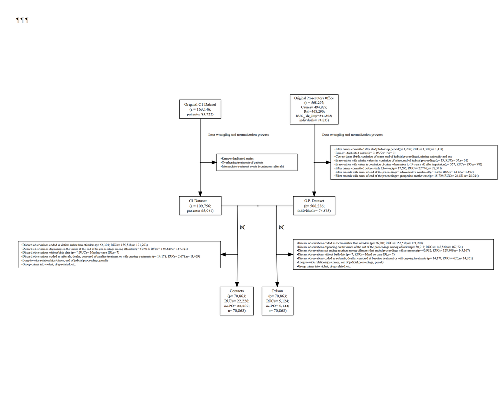

```r
htmlwidgets::saveWidget(plot_merge_flowchart_after_dates, paste0(sub("2019 \\(github\\)/SUD_CL","2022 \\(github\\)",path),"/_figs/_flowchart_merge_222_3.html"))
webshot::webshot(paste0(sub("2019 \\(github\\)/SUD_CL","2022 \\(github\\)",path),"/_figs/_flowchart_merge_222_3.html"), paste0(sub("2019 \\(github\\)/SUD_CL","2022 \\(github\\)",path),"/_figs/_flowchart_merge_formatted_3.png"),vwidth = 1200, vheight = 900,
        zoom = 2)
```

Time for this code chunk to run: 0 minutes

# Label

```r
vars_desc <- c("age_offending_imp", "edad_al_egres_imp", "fech_nac_rec", "motivodeegreso_mod_imp_rec")

list_codebook <- list(

hash_key = "Hash (ID)",

edad_al_ing_1 =  "Age (admission to treatment)",
edad_ini_cons =  "Age of Onset of Substance Use", # I added it
dias_treat_imp_sin_na_1 =  "Days in treatment",
sex =  "Sex",
escolaridad_rec =  "Educational Attainment",
sus_principal_mod = "Primary Substance (admission to treatment)",
freq_cons_sus_prin =  "Substance use frequency (primary substance)",
compromiso_biopsicosocial =  "Bio-psychosocial status",
tenencia_de_la_vivienda_mod =  "Housing situation (tenure status of households)",
dg_cie_10_rec =  "Comorbidity (ICD-10)",
dg_trs_cons_sus_or =  "SUD Severity (Dependence status)",
macrozona =  "Macro administrative Chilean zone",
policonsumo =  "Co-occurring SUD",
tr_modality =  "Treatment Modality",

#Added in 2022-11-11
tipo_centro = "Center ID",
condicion_ocupacional_cor = "Occupational Status Corrected",
origen_ingreso_mod = "Motive of Admission to Treatment",
numero_de_hijos_mod = "Number of Children ",

motivodeegreso_mod_imp_rec = "Baseline treatment status",
edad_al_ing_1 = "Age at admission (mod)",
fech_egres_imp = "Date of discharge",

n_prev_off =  "Pre-treatment Criminality (Dich.)",
n_off_vio =  "Violent crime, Pre-treatment Criminality",
n_off_acq =  "Acquisitive crime, Pre-treatment Criminality",
n_off_sud =  "Substance use-related crime, Pre-treatment Criminality",
n_off_oth =  "Other crime, Pre-treatment Criminality",
age_offending_imp = "Age when the offense was committed",
edad_al_egres_imp = "Age at discharge (mod)",
fech_nac_rec = "Corrected date of birth",
motivodeegreso_mod_imp_rec = "Treatment status",
time_to_off_from_adm = "Time-to-offense from Admission",
time_to_off_from_disch =  "Time-to-offense from Discharge",
id_centro = "Treatment center ID",
comuna_residencia_cod = "Municipality or District of Residence",
fech_ing_num_1 = "Date of admission",

#added
cut_com_del =  "Binned comission date",
cut_fec_nac =  "Binned birth date"
)

codebook::var_label(Base_fiscalia_v13)<- list_codebook
codebook::var_label(Base_fiscalia_v13_pris)<- list_codebook
```

Time for this code chunk to run: 0 minutes

# Session Info

```r
message(Sys.getenv("R_LIBS_USER"))
```

C:/Users/CISS Fondecyt/Mi unidad/Alvacast/SISTRAT 2022 (github)/renv/library/R-4.1/x86_64-w64-mingw32;C:/Users/CISS Fondecyt/AppData/Local/Temp/Rtmp2TCdxw/renv-system-library

```r
Sys.Date()
```

```
[1] "2023-01-05"
```

```r
message(paste0("Editor context: ", path))
```

Editor context: C:/Users/CISS Fondecyt/Mi unidad/Alvacast/SISTRAT 2022 (github)

```r
if (grepl("CISS Fondecyt",rstudioapi::getSourceEditorContext()$path)==T){
    save.image("C:/Users/CISS Fondecyt/Mi unidad/Alvacast/SISTRAT 2022 (github)/14.RData")
  } else if (grepl("andre",rstudioapi::getSourceEditorContext()$path)==T){
    save.image("C:/Users/andre/Desktop/SUD_CL/14.RData")
  } else if (grepl("E:",rstudioapi::getSourceEditorContext()$path)==T){
    save.image("E:/Mi unidad/Alvacast/SISTRAT 2022 (github)/14.RData")
  } else {
    save.image(paste0(sub("2019","2022",sub("SUD_CL","",path)),"14.RData"))
  }

sesion_info <- devtools::session_info()
dplyr::select(
  tibble::as_tibble(sesion_info$packages),
  c(package, loadedversion, source)
) %>%
  DT::datatable(filter = 'top', colnames = c('Row number' =1,'Variable' = 2, 'Percentage'= 3),
              caption = htmltools::tags$caption(
        style = 'caption-side: top; text-align: left;',
        '', htmltools::em('Packages')),
      options=list(
initComplete = htmlwidgets::JS(
        "function(settings, json) {",
        "$(this.api().tables().body()).css({
            'font-family': 'Helvetica Neue',
            'font-size': '50%',
            'code-inline-font-size': '15%',
            'white-space': 'nowrap',
            'line-height': '0.75em',
            'min-height': '0.5em'
            });",#;
        "}")))
```

| Row number | Variable | Percentage | source |
| --- | --- | --- | --- |
| 1 | abind | 1.4-5 | CRAN (R 4.1.1) |
| 2 | adjustedCurves | 0.9.0 | CRAN (R 4.1.3) |
| 3 | admisc | 0.30 | CRAN (R 4.1.3) |
| 4 | Amelia | 1.8.0 | CRAN (R 4.1.2) |
| 5 | APCtools | 1.0.1 | CRAN (R 4.1.3) |
| 6 | assertthat | 0.2.1 | CRAN (R 4.1.2) |
| 7 | backports | 1.4.1 | CRAN (R 4.1.2) |
| 8 | base64enc | 0.1-3 | CRAN (R 4.1.1) |
| 9 | bayestestR | 0.13.0 | CRAN (R 4.1.3) |
| 10 | BiasedUrn | 1.07 | CRAN (R 4.1.1) |

[output cut: 302 more lines]

Time for this code chunk to run: 0.1 minutes

# Export

```r
subset(Base_fiscalia_v13, select=c("hash_key", cont_vars_desc, cat_vars_desc, cat_vars_desc_off, vars_desc, "id_centro", "comuna_residencia_cod", "fech_ing_num_1", "fech_egres_imp", "cut_com_del", "cut_fec_nac","offender_d")) %>%
  dplyr::arrange(hash_key, fech_ing_num_1) %>%
  data.table::data.table() %>%
  rio::export(file = paste0("fiscalia_mariel_oct_2022_match_SENDA.dta"))

subset(Base_fiscalia_v13_pris, select=c("hash_key", cont_vars_desc, cat_vars_desc, cat_vars_desc_off, vars_desc, "id_centro", "comuna_residencia_cod", "fech_ing_num_1", "fech_egres_imp", "cut_com_del", "cut_fec_nac","offender_d")) %>%
  dplyr::arrange(hash_key, fech_ing_num_1) %>%
  data.table::data.table() %>%
  rio::export(file = paste0("fiscalia_mariel_oct_2022_match_SENDA_pris.dta"))
```

Time for this code chunk to run: 0 minutes

```r
#put name of the file
file<- "fiscalia_mariel_oct_2022_match_SENDA.dta"

export_lab_stata_merge<-
  tibble::rownames_to_column(data.frame(Hmisc::label(dplyr::select(Base_fiscalia_v13,  all_of(c("hash_key", cont_vars_desc, cat_vars_desc, cat_vars_desc_off, vars_desc, "fech_ing_num_1", "fech_egres_imp", "cut_com_del", "cut_fec_nac","offender_d"))))))%>% data.frame() %>%
  dplyr::rename("code" = !!names(.[1]), "label" = !!names(.[2]))%>% data.frame()%>%
  dplyr::mutate(first= "cap noi label variable")%>%
  dplyr::mutate(final= paste0(first, " ",code,' "',label,'"'))%>%
  dplyr::select(-code,-label,-first)%>%
  dplyr::rename("*clear all"="final") %>%
  rbind(paste0('cap noi save "', gsub('/', '\\', path, fixed=T),'\\',file,'", replace'))%>%
  rbind(paste0('cap noi save "', gsub('/', '\\', path, fixed=T),'\\',file,'", replace'))

rbind(paste0('cap noi use "', gsub('/', '\\', path, fixed=T),'\\',file,'", clear'),export_lab_stata_merge) %>% knitr::kable("markdown")
```

| *clear all |
| --- |
| cap noi use “C:Fondecytunidad (github)_mariel_oct_2022_match_SENDA.dta”, clear |
| cap noi label variable hash_key “Hash (ID)” |
| cap noi label variable edad_al_ing_1 “Age (admission to treatment)” |
| cap noi label variable edad_ini_cons “Age of Onset of Substance Use” |
| cap noi label variable dias_treat_imp_sin_na_1 “Days in treatment” |
| cap noi label variable sex “Sex” |
| cap noi label variable escolaridad_rec “Educational Attainment” |
| cap noi label variable sus_principal_mod “Primary Substance (admission to treatment)” |
| cap noi label variable freq_cons_sus_prin “Substance use frequency (primary substance)” |
| cap noi label variable compromiso_biopsicosocial “Bio-psychosocial status” |
| cap noi label variable tenencia_de_la_vivienda_mod “Housing situation (tenure status of households)” |
| cap noi label variable dg_cie_10_rec “Comorbidity (ICD-10)” |
| cap noi label variable dg_trs_cons_sus_or “SUD Severity (Dependence status)” |
| cap noi label variable macrozona “Macro administrative Chilean zone” |
| cap noi label variable policonsumo “Co-occurring SUD” |
| cap noi label variable tr_modality “Treatment Modality” |
| cap noi label variable tipo_centro “Center ID” |
| cap noi label variable condicion_ocupacional_cor “Occupational Status Corrected” |
| cap noi label variable origen_ingreso_mod “Motive of Admission to Treatment” |
| cap noi label variable numero_de_hijos_mod “Number of Children” |
| cap noi label variable n_prev_off “Pre-treatment Criminality (Dich.)” |
| cap noi label variable n_off_vio “Violent crime, Pre-treatment Criminality” |
| cap noi label variable n_off_acq “Acquisitive crime, Pre-treatment Criminality” |
| cap noi label variable n_off_sud “Substance use-related crime, Pre-treatment Criminality” |
| cap noi label variable n_off_oth “Other crime, Pre-treatment Criminality” |
| cap noi label variable age_offending_imp “Age when the offense was committed” |
| cap noi label variable edad_al_egres_imp “Age at discharge (mod)” |
| cap noi label variable fech_nac_rec “Corrected date of birth” |
| cap noi label variable motivodeegreso_mod_imp_rec “Baseline treatment status” |
| cap noi label variable fech_ing_num_1 “Date of admission” |
| cap noi label variable fech_egres_imp “Date of discharge” |
| cap noi label variable cut_com_del “Binned comission date” |
| cap noi label variable cut_fec_nac “Binned birth date” |
| cap noi label variable offender_d “” |
| cap noi save “C:Fondecytunidad (github)_mariel_oct_2022_match_SENDA.dta”, replace |
| cap noi save “C:Fondecytunidad (github)_mariel_oct_2022_match_SENDA.dta”, replace |

```r
write.table(rbind(paste0('cap noi use "', gsub('/', '\\', path, fixed=T),'\\',file,'", clear'),export_lab_stata_merge), file = paste0(path,"/_label_var_to_stata.do"), sep = "",row.names = FALSE, quote = FALSE, fileEncoding="UTF-8")
```

Time for this code chunk to run: 0 minutes

```stata
*should be in the same folder of the .Rmd to work
cap noi do _label_var_to_stata.do
```

```
Error in running command st
```

Time for this code chunk to run: 0 minutes